# **Business Case: Yulu - Confidence Interval and CLT**

> - [Yulu Data_Set](https://d2beiqkhq929f0.cloudfront.net/public_assets/assets/000/001/428/original/bike_sharing.csv?1642089089)
> - [Yulu Project Sebmision Link](https://www.scaler.com/academy/mentee-dashboard/class/104707/project/problems/17195?navref=cl_tt_crd_sl)

```python
import numpy as np
import pandas as pd
import seaborn as sns
import matplotlib.pyplot as plt

import math
from scipy import stats
from scipy.stats import norm, binom, geom, poisson  # Distributions
from scipy.stats import zscore, ttest_1samp, ttest_ind, ttest_rel  # Z-Test & T-Test
from scipy.stats import chisquare, chi2_contingency, chi2  # ChiSquare Test
from scipy.stats import f_oneway, kruskal, shapiro, levene, ks_2samp  # Anova Test
from scipy.stats import pearsonr, spearmanr  # Co-Relation Test
from scipy.stats import shapiro  # Co-Relation Test

from statsmodels.graphics.gofplots import qqplot

import warnings
warnings.filterwarnings("ignore")

sns.set_theme(style="darkgrid")
```

## **Mindset**

- Evaluation will be kept lenient, so make sure you attempt this case study.
- It is understandable that you might struggle with getting started on this. Just brainstorm, discuss with peers, or get help from TAs.
- There is no right or wrong answer. We have to become comfortable with dealing with uncertainty in business.
  - This is exactly the skill we want to develop.

## **About Yulu**

- Yulu is India’s leading micro-mobility service provider, which offers unique vehicles for the daily commute. Starting off as a mission to eliminate traffic congestion in India, Yulu provides the safest commute solution through a user-friendly mobile app to enable shared, solo and sustainable commuting.
- Yulu zones are located at all the appropriate locations (including metro stations, bus stands, office spaces, residential areas, corporate offices, etc) to make those first and last miles smooth, affordable, and convenient!
- Yulu has recently suffered considerable dips in its revenues. They have contracted a consulting company to understand the factors on which the demand for these shared electric cycles depends. Specifically, they want to understand the factors affecting the demand for these shared electric cycles in the Indian market.

## **About DataSet**

- datetime: datetime
- season: season `(1: spring, 2: summer, 3: fall, 4: winter)`
- holiday: whether day is a holiday or not (extracted from http://dchr.dc.gov/page/holiday-schedule)
- workingday: if day is neither weekend nor holiday is 1, otherwise is 0.
- weather:
  - 1: `Clear, Few clouds, partly cloudy, partly cloudy`
  - 2: `Mist + Cloudy, Mist + Broken clouds, Mist + Few clouds, Mist`
  - 3: `Light Snow, Light Rain + Thunderstorm + Scattered clouds, Light Rain + Scattered clouds`
  - 4: `Heavy Rain + Ice Pallets + Thunderstorm + Mist, Snow + Fog`
- temp: temperature in Celsius
- atemp: feeling temperature in Celsius
- humidity: humidity
- windspeed: wind speed
- casual: count of casual users
- registered: count of registered users
- count: count of total rental bikes including both casual and registered

```python
yulu_raw = pd.read_csv("./bike_sharing.csv", parse_dates=[0], dayfirst=True)
yulu_raw.head(5)
```

|  | datetime | season | holiday | workingday | weather | temp | atemp | humidity | windspeed | casual | registered | count |
| --- | --- | --- | --- | --- | --- | --- | --- | --- | --- | --- | --- | --- |
| 0 | 2011-01-01 00:00:00 | 1 | 0 | 0 | 1 | 9.84 | 14.395 | 81 | 0.0 | 3 | 13 | 16 |
| 1 | 2011-01-01 01:00:00 | 1 | 0 | 0 | 1 | 9.02 | 13.635 | 80 | 0.0 | 8 | 32 | 40 |
| 2 | 2011-01-01 02:00:00 | 1 | 0 | 0 | 1 | 9.02 | 13.635 | 80 | 0.0 | 5 | 27 | 32 |
| 3 | 2011-01-01 03:00:00 | 1 | 0 | 0 | 1 | 9.84 | 14.395 | 75 | 0.0 | 3 | 10 | 13 |
| 4 | 2011-01-01 04:00:00 | 1 | 0 | 0 | 1 | 9.84 | 14.395 | 75 | 0.0 | 0 | 1 | 1 |

```python
confidence_interval = 99/100
# # confidence_interval = 99%
significance_level = 1-confidence_interval
# $ significance_level = 1%
```

## **Business Problem**

The company wants to know:

- Which variables are significant in predicting the demand for shared electric cycles in the Indian market?
- How well those variables describe the electric cycle demands

## **Exploring The Data Set**

```python
yulu_raw.shape
```

```
(10886, 12)
```

```python
yulu_raw.info()
```

```
<class 'pandas.core.frame.DataFrame'>
RangeIndex: 10886 entries, 0 to 10885
Data columns (total 12 columns):
 #   Column      Non-Null Count  Dtype
---  ------      --------------  -----
 0   datetime    10886 non-null  datetime64[ns]
 1   season      10886 non-null  int64
 2   holiday     10886 non-null  int64
 3   workingday  10886 non-null  int64
 4   weather     10886 non-null  int64
 5   temp        10886 non-null  float64
 6   atemp       10886 non-null  float64
 7   humidity    10886 non-null  int64
 8   windspeed   10886 non-null  float64
 9   casual      10886 non-null  int64
 10  registered  10886 non-null  int64
 11  count       10886 non-null  int64
dtypes: datetime64[ns](1), float64(3), int64(8)
memory usage: 1020.7 KB
```

### **Missing value detection & fill with relevent data.**

```python
yulu_raw.isnull().sum()
```

```
datetime      0
season        0
holiday       0
workingday    0
weather       0
temp          0
atemp         0
humidity      0
windspeed     0
casual        0
registered    0
count         0
dtype: int64
```

### **Check for Outliers**

```python
def check_outlier(df, x):
    Q1 = df[x].quantile(0.25)
    Q3 = df[x].quantile(0.75)
    IQR = Q3 - Q1
    lower = Q1 - 1.5*IQR
    upper = Q3 + 1.5*IQR
    lower_outlier = df[x][df[x] < lower]
    upper_outlier = df[x][df[x] > upper]

    return {
        'lower': {
            'list': lower_outlier,
            'length': len(lower_outlier)
        },
        'upper': {
            'list': upper_outlier,
            'length': len(upper_outlier)
        }}
```

```python
for i in yulu_raw[['humidity', 'windspeed', 'count', 'temp', 'atemp', 'casual', 'registered']].columns:
    # print(i)
    outlier = check_outlier(yulu_raw, i)
    print("{} : \n\t'Lower Outliers': {} \n\t'Higher Outliers': {} \n\t'Mean - Median': {}\n".format(i,
          outlier['lower']['length'], outlier['upper']['length'], round(yulu_raw[i].mean()-yulu_raw[i].median(), 4)))
```

```
humidity :
	'Lower Outliers': 22
	'Higher Outliers': 0
	'Mean - Median': -0.1135

windspeed :
	'Lower Outliers': 0
	'Higher Outliers': 227
	'Mean - Median': -0.1986

count :
	'Lower Outliers': 0
	'Higher Outliers': 300
	'Mean - Median': 46.5741

temp :
	'Lower Outliers': 0
	'Higher Outliers': 0
	'Mean - Median': -0.2691

atemp :
	'Lower Outliers': 0
	'Higher Outliers': 0
	'Mean - Median': -0.5849

casual :
	'Lower Outliers': 0
	'Higher Outliers': 749
	'Mean - Median': 19.022

registered :
	'Lower Outliers': 0
	'Higher Outliers': 423
	'Mean - Median': 37.5522
```

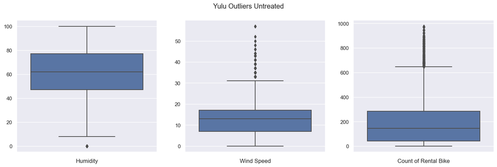

```python
plt.figure(figsize=(18, 5)).suptitle(" Yulu Outliers Untreated")
plt.subplot(1, 3, 1)
sns.boxplot(yulu_raw, y='humidity')
plt.xlabel("Humidity")
plt.ylabel("")
plt.subplot(1, 3, 2)
sns.boxplot(yulu_raw, y='windspeed')
plt.xlabel("Wind Speed")
plt.ylabel("")
plt.subplot(1, 3, 3)
sns.boxplot(yulu_raw, y='count')
plt.xlabel("Count of Rental Bike")
plt.ylabel("")
plt.show()
```

### **Remove Outliers**

```python
def remove_outlier(df, x):
    Q1 = df[x].quantile(0.25)
    Q3 = df[x].quantile(0.75)
    IQR = Q3 - Q1
    lower = Q1 - 1.5*IQR
    upper = Q3 + 1.5*IQR

    # print((lower-df[x].mean())/df[x].std())
    # print((upper-df[x].mean())/df[x].std())
    # print(df.shape, x, lower, upper)

    return df[(df[x] > lower) & (df[x] < upper)]
```

```python
for i in yulu_raw[['humidity', 'windspeed', 'count']].columns:
    # print(i)
    yulu_raw = remove_outlier(yulu_raw, i)
    print(yulu_raw.shape)
```

```
(10864, 12)
(10638, 12)
(10352, 12)
```

```python
# humidity_z = np.abs(stats.zscore(yulu_raw['humidity']))
# windspeed_z = np.abs(stats.zscore(yulu_raw['windspeed']))
# count_z = np.abs(stats.zscore(yulu_raw['count']))
# threshold = 3
# yulu_raw[((humidity_z < 3) & (humidity_z > -3))]
# yulu_raw = yulu_raw[((windspeed_z < 3) & (windspeed_z > -3))]
# yulu_raw = yulu_raw[((count_z < 3) & (count_z > -3))]
# yulu_raw.shape
```

```python
for i in yulu_raw[['humidity', 'windspeed', 'count']].columns:
    # print(i)
    outlier = check_outlier(yulu_raw, i)
    print("{} : \n\t'Lower Outliers': {} \n\t'Higher Outliers': {} \n\t'Mean - Median': {}\n".format(i,
          outlier['lower']['length'], outlier['upper']['length'], round(yulu_raw[i].mean()-yulu_raw[i].median(), 4)))
```

```
humidity :
	'Lower Outliers': 0
	'Higher Outliers': 0
	'Mean - Median': 0.6235

windspeed :
	'Lower Outliers': 0
	'Higher Outliers': 0
	'Mean - Median': 1.2663

count :
	'Lower Outliers': 0
	'Higher Outliers': 77
	'Mean - Median': 37.3668
```

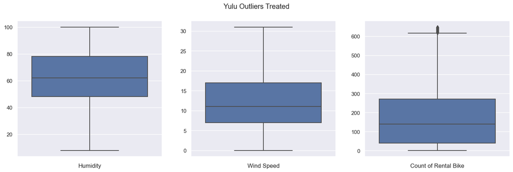

```python
plt.figure(figsize=(18, 5)).suptitle(" Yulu Outliers Treated")
plt.subplot(1, 3, 1)
sns.boxplot(yulu_raw, y='humidity')
plt.xlabel("Humidity")
plt.ylabel("")
plt.subplot(1, 3, 2)
sns.boxplot(yulu_raw, y='windspeed')
plt.xlabel("Wind Speed")
plt.ylabel("")
plt.subplot(1, 3, 3)
sns.boxplot(yulu_raw, y='count')
plt.xlabel("Count of Rental Bike")
plt.ylabel("")
plt.show()
```

### **Consolidated Data**

```python
df_yulu = yulu_raw.copy()
```

```python
df_yulu.columns
```

```
Index(['datetime', 'season', 'holiday', 'workingday', 'weather', 'temp',
       'atemp', 'humidity', 'windspeed', 'casual', 'registered', 'count'],
      dtype='object')
```

#### `Time Slots` of the Day

```python
df_yulu["time_slot"] = yulu_raw['datetime'].dt.hour.apply(
    lambda x:
    ("Dawn" if (x <= 4) else
     ("Early Morning" if (x <= 9) else
      ("Noon" if (x <= 16) else
       ("Late Evening" if (
           x <= 21) else "Night")
       )
      )
     )
)
```

#### `Set Name` to Categorical Columns

```python
def season_convert(x):
    return 'Spring' if (int(x) == 1) else ("Summer" if (int(x) == 2) else ("Fall" if (int(x) == 3) else "Winter"))


def holiday_convert(x):
    return 'Yes' if (int(x) == 1) else 'No'


def workingday_convert(x):
    return 'Yes' if (int(x) == 1) else 'No'


def weather_convert(x):
    return 'Clear or Cloudy' if (int(x) == 1) else ("Mist" if (int(x) == 2) else ("Light Rain or Snow" if (int(x) == 3) else "Heavy Rain or Snow"))
```

```python
df_yulu['season'] = yulu_raw.apply(
    lambda row: season_convert(row['season']), axis=1)
df_yulu['holiday'] = yulu_raw.apply(
    lambda row: holiday_convert(row['holiday']), axis=1)
df_yulu['workingday'] = yulu_raw.apply(
    lambda row: workingday_convert(row['workingday']), axis=1)
df_yulu['weather'] = yulu_raw.apply(
    lambda row: weather_convert(row['weather']), axis=1)
```

```python
df_yulu = df_yulu[['datetime', 'time_slot', 'season', 'holiday', 'workingday', 'weather', 'temp',
                   'atemp', 'humidity', 'windspeed', 'casual', 'registered', 'count']]
df_yulu.head(5)
```

|  | datetime | time_slot | season | holiday | workingday | weather | temp | atemp | humidity | windspeed | casual | registered | count |
| --- | --- | --- | --- | --- | --- | --- | --- | --- | --- | --- | --- | --- | --- |
| 0 | 2011-01-01 00:00:00 | Dawn | Spring | No | No | Clear or Cloudy | 9.84 | 14.395 | 81 | 0.0 | 3 | 13 | 16 |
| 1 | 2011-01-01 01:00:00 | Dawn | Spring | No | No | Clear or Cloudy | 9.02 | 13.635 | 80 | 0.0 | 8 | 32 | 40 |
| 2 | 2011-01-01 02:00:00 | Dawn | Spring | No | No | Clear or Cloudy | 9.02 | 13.635 | 80 | 0.0 | 5 | 27 | 32 |
| 3 | 2011-01-01 03:00:00 | Dawn | Spring | No | No | Clear or Cloudy | 9.84 | 14.395 | 75 | 0.0 | 3 | 10 | 13 |
| 4 | 2011-01-01 04:00:00 | Dawn | Spring | No | No | Clear or Cloudy | 9.84 | 14.395 | 75 | 0.0 | 0 | 1 | 1 |

#### `Binning` of Countinuous Columns

```python
df_yulu_grouped = df_yulu.copy()
```

```python
def temp_categorise(df):
    df["temp_group"] = pd.cut(x=df['temp'], bins=[-5, 0, 5, 10, 15, 20, 25, 30, 35, 40, 45],
                              labels=["< 0.0", '0.1 to 5.0', "5.1 to 10.0", "10.1 to 15.0", "15.1 to 20.0", "20.1 to 25.0", "25.1 to 30.0", "30.1 to 35.0", "35.1 to 40.0", "> 40.0"])
    df['temp_group'] = df['temp_group'].astype('category')
    return df


def atemp_categorise(df):
    df["atemp_group"] = pd.cut(x=df['atemp'], bins=[-5, 0, 5, 10, 15, 20, 25, 30, 35, 40, 45, 50],
                               labels=["< 0.0", '0.1 to 5.0', "5.1 to 10.0", "10.1 to 15.0", "15.1 to 20.0", "20.1 to 25.0", "25.1 to 30.0", "30.1 to 35.0", "35.1 to 40.0", "40.1 to 45.0", "> 45.0"])
    df['atemp_group'] = df['atemp_group'].astype('category')
    return df


def humidity_categorise(df):
    df["humidity_group"] = pd.cut(x=df['humidity'], bins=[-1, 10, 20, 30, 40, 50, 60, 70, 80, 90, 100],
                                  labels=['0.0-10.0 %', '10.1-20.0 %', '20.1-30.0 %', '30.1-40.0 %', '40.1-50.0 %', '50.1-60.0 %', '60.1-70.0 %', '70.1-80.0 %', '80.1-90.0 %', '90.1-100.0 %'])
    df['humidity_group'] = df['humidity_group'].astype('category')
    return df


def windspeed_categorise(df):
    df["windspeed_group"] = pd.cut(x=df['windspeed'], bins=[-1.0, 10, 20, 30, 40, 50, 60],
                                   labels=['0.0-10.0', '10.1-20.0', '20.1-30.0', '30.1-40.0', '40.1-50.0', '50.1-60.0'])
    df['windspeed_group'] = df['windspeed_group'].astype('category')
    return df


def casualUser_categorise(df):
    df["casual_group"] = pd.cut(x=df[df['casual'] != 0]['casual'], bins=[-1.0, 100, 200, 300, 400],
                                labels=['0-100', '101-200', '201-300', '301-400'])
    df['casual_group'] = df['casual_group'].astype('category')
    return df


def registeredUser_categorise(df):
    df["registered_group"] = pd.cut(x=df[df['registered'] != 0]['registered'], bins=[-1.0, 100, 200, 300, 400, 500, 600, 700],
                                    labels=['0-100', '101-200', '201-300', '301-400', '401-500', '501-600', '601-700'])
    df['registered_group'] = df['registered_group'].astype('category')
    return df


def count_categorise(df):
    df["count_group"] = pd.cut(x=df['count'], bins=[-1.0, 100, 200, 300, 400, 500, 600, 700],
                               labels=['0-100', '101-200', '201-300', '301-400', '401-500', '501-600', '601-700'])
    df['count_group'] = df['count_group'].astype('category')
    return df
```

```python
df_yulu_grouped = temp_categorise(df_yulu_grouped)
df_yulu_grouped = atemp_categorise(df_yulu_grouped)
df_yulu_grouped = humidity_categorise(df_yulu_grouped)
df_yulu_grouped = windspeed_categorise(df_yulu_grouped)
df_yulu_grouped = casualUser_categorise(df_yulu_grouped)
df_yulu_grouped = registeredUser_categorise(df_yulu_grouped)
df_yulu_grouped = count_categorise(df_yulu_grouped)
```

```python
df_yulu_grouped.info()
```

```
<class 'pandas.core.frame.DataFrame'>
Int64Index: 10352 entries, 0 to 10885
Data columns (total 20 columns):
 #   Column            Non-Null Count  Dtype
---  ------            --------------  -----
 0   datetime          10352 non-null  datetime64[ns]
 1   time_slot         10352 non-null  object
 2   season            10352 non-null  object
 3   holiday           10352 non-null  object
 4   workingday        10352 non-null  object
 5   weather           10352 non-null  object
 6   temp              10352 non-null  float64
 7   atemp             10352 non-null  float64
 8   humidity          10352 non-null  int64
 9   windspeed         10352 non-null  float64
 10  casual            10352 non-null  int64
 11  registered        10352 non-null  int64
 12  count             10352 non-null  int64
 13  temp_group        10352 non-null  category
 14  atemp_group       10352 non-null  category
 15  humidity_group    10352 non-null  category
 16  windspeed_group   10352 non-null  category
 17  casual_group      9391 non-null   category
 18  registered_group  10339 non-null  category
 19  count_group       10352 non-null  category
dtypes: category(7), datetime64[ns](1), float64(3), int64(4), object(5)
memory usage: 1.2+ MB
```

#### `Updated` Yulu Data Set

```python
df_yulu.info()
```

```
<class 'pandas.core.frame.DataFrame'>
Int64Index: 10352 entries, 0 to 10885
Data columns (total 13 columns):
 #   Column      Non-Null Count  Dtype
---  ------      --------------  -----
 0   datetime    10352 non-null  datetime64[ns]
 1   time_slot   10352 non-null  object
 2   season      10352 non-null  object
 3   holiday     10352 non-null  object
 4   workingday  10352 non-null  object
 5   weather     10352 non-null  object
 6   temp        10352 non-null  float64
 7   atemp       10352 non-null  float64
 8   humidity    10352 non-null  int64
 9   windspeed   10352 non-null  float64
 10  casual      10352 non-null  int64
 11  registered  10352 non-null  int64
 12  count       10352 non-null  int64
dtypes: datetime64[ns](1), float64(3), int64(4), object(5)
memory usage: 1.1+ MB
```

### **Conversion of categorical attributes to 'category'.**

```python
df_yulu['time_slot'] = df_yulu['time_slot'].astype('category')
df_yulu['season'] = df_yulu['season'].astype('category')
df_yulu['holiday'] = df_yulu['holiday'].astype('category')
df_yulu['workingday'] = df_yulu['workingday'].astype('category')
df_yulu['weather'] = df_yulu['weather'].astype('category')
df_yulu.info()
```

```
<class 'pandas.core.frame.DataFrame'>
Int64Index: 10352 entries, 0 to 10885
Data columns (total 13 columns):
 #   Column      Non-Null Count  Dtype
---  ------      --------------  -----
 0   datetime    10352 non-null  datetime64[ns]
 1   time_slot   10352 non-null  category
 2   season      10352 non-null  category
 3   holiday     10352 non-null  category
 4   workingday  10352 non-null  category
 5   weather     10352 non-null  category
 6   temp        10352 non-null  float64
 7   atemp       10352 non-null  float64
 8   humidity    10352 non-null  int64
 9   windspeed   10352 non-null  float64
 10  casual      10352 non-null  int64
 11  registered  10352 non-null  int64
 12  count       10352 non-null  int64
dtypes: category(5), datetime64[ns](1), float64(3), int64(4)
memory usage: 779.3 KB
```

### **Statitical Summary**

#### Descriptive `Statistits`

```python
df_yulu[['time_slot', 'season', 'holiday', 'workingday', 'weather']].describe()
```

|  | time_slot | season | holiday | workingday | weather |
| --- | --- | --- | --- | --- | --- |
| count | 10352 | 10352 | 10352 | 10352 | 10352 |
| unique | 5 | 4 | 2 | 2 | 4 |
| top | Noon | Winter | No | Yes | Clear or Cloudy |
| freq | 3044 | 2645 | 10049 | 6992 | 6821 |

```python
df_yulu[['temp', 'atemp', 'humidity', 'windspeed',
         'casual', 'registered', 'count']].describe()
```

|  | temp | atemp | humidity | windspeed | casual | registered | count |
| --- | --- | --- | --- | --- | --- | --- | --- |
| count | 10352.000000 | 10352.000000 | 10352.000000 | 10352.000000 | 10352.000000 | 10352.000000 | 10352.000000 |
| mean | 20.114397 | 23.551453 | 62.623454 | 12.267712 | 34.136785 | 142.230004 | 176.366789 |
| std | 7.784824 | 8.443686 | 18.869422 | 7.458563 | 47.224470 | 127.388471 | 156.952045 |
| min | 0.820000 | 0.760000 | 8.000000 | 0.000000 | 0.000000 | 0.000000 | 1.000000 |
| 25% | 13.940000 | 16.665000 | 48.000000 | 7.001500 | 4.000000 | 34.000000 | 40.000000 |
| 50% | 20.500000 | 24.240000 | 62.000000 | 11.001400 | 16.000000 | 114.000000 | 139.000000 |
| 75% | 26.240000 | 31.060000 | 78.000000 | 16.997900 | 46.000000 | 212.000000 | 271.000000 |
| max | 41.000000 | 45.455000 | 100.000000 | 31.000900 | 355.000000 | 629.000000 | 649.000000 |

#### Unique Count

```python
df_yulu.nunique()
```

```
datetime      10352
time_slot         5
season            4
holiday           2
workingday        2
weather           4
temp             49
atemp            60
humidity         87
windspeed        16
casual          285
registered      586
count           643
dtype: int64
```

#### Mean

```python
df_yulu[['temp', 'atemp', 'humidity', 'windspeed',
         'casual', 'registered', 'count']].mean()
```

```
temp           20.114397
atemp          23.551453
humidity       62.623454
windspeed      12.267712
casual         34.136785
registered    142.230004
count         176.366789
dtype: float64
```

#### Median

```python
df_yulu[['temp', 'atemp', 'humidity', 'windspeed',
         'casual', 'registered', 'count']].median()
```

```
temp           20.5000
atemp          24.2400
humidity       62.0000
windspeed      11.0014
casual         16.0000
registered    114.0000
count         139.0000
dtype: float64
```

#### Mode

```python
for i in df_yulu.columns:
    print(i, ':', df_yulu[i].mode()[0])
```

```
datetime : 2011-01-01 00:00:00
time_slot : Noon
season : Winter
holiday : No
workingday : Yes
weather : Clear or Cloudy
temp : 14.76
atemp : 31.06
humidity : 88
windspeed : 0.0
casual : 0
registered : 3
count : 5
```

## **Uni Variate Analysis**

### **Time Slot**

```python
df_yulu['time_slot'].unique()
```

```
['Dawn', 'Early Morning', 'Noon', 'Late Evening', 'Night']
Categories (5, object): ['Dawn', 'Early Morning', 'Late Evening', 'Night', 'Noon']
```

```python
df_yulu['time_slot'].value_counts()
```

```
Noon             3044
Dawn             2207
Early Morning    2168
Late Evening     2035
Night             898
Name: time_slot, dtype: int64
```

```python
df_yulu['time_slot'].value_counts(normalize=True)*100
```

```
Noon             29.404946
Dawn             21.319552
Early Morning    20.942813
Late Evening     19.658037
Night             8.674652
Name: time_slot, dtype: float64
```

#### **Statitical Analysis**

```python
df_yulu['time_slot'].describe()
```

```
count     10352
unique        5
top        Noon
freq       3044
Name: time_slot, dtype: object
```

```python
df_yulu['time_slot'].mode()[0]
```

```
'Noon'
```

```python
df_yulu.groupby('time_slot')["count"].describe()
```

| time_slot | count | mean | std | min | 25% | 50% | 75% | max |
| --- | --- | --- | --- | --- | --- | --- | --- | --- |
| Dawn | 2207.0 | 26.500227 | 33.237161 | 1.0 | 5.00 | 12.0 | 34.00 | 283.0 |
| Early Morning | 2168.0 | 161.540129 | 154.698997 | 1.0 | 29.75 | 112.0 | 258.25 | 649.0 |
| Late Evening | 2035.0 | 286.374447 | 157.208013 | 11.0 | 165.00 | 262.0 | 397.00 | 649.0 |
| Night | 898.0 | 112.462138 | 65.169543 | 4.0 | 61.25 | 105.0 | 152.00 | 502.0 |
| Noon | 3044.0 | 240.893890 | 135.166752 | 3.0 | 138.00 | 216.0 | 323.00 | 647.0 |

#### **Plot the Graph**

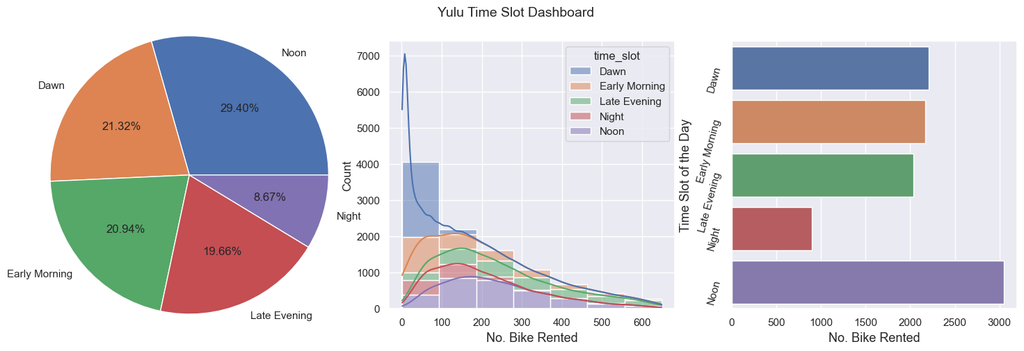

```python
plt.figure(figsize=(18, 5)).suptitle(
    "Yulu Time Slot Dashboard", fontsize=14)

plt.subplot(1, 3, 1)
plt.pie(df_yulu['time_slot'].value_counts().values, labels=df_yulu['time_slot'].value_counts(
).index, radius=1.3, autopct='%1.2f%%',)  # type: ignore

plt.subplot(1, 3, 2)
sns.histplot(data=df_yulu, x='count', bins=7,
             hue='time_slot', kde=True, multiple="stack")
plt.xlabel('No. Bike Rented', fontsize=13)
plt.ylabel("Count", fontsize=12)

plt.subplot(1, 3, 3)
sns.countplot(df_yulu, y='time_slot')
plt.xlabel("No. Bike Rented", fontsize=13)
plt.ylabel('Time Slot of the Day', fontsize=13)
plt.xticks(rotation=0, fontsize=11)
plt.yticks(rotation=75, fontsize=11)

plt.show()
```

### **Season**

```python
df_yulu['season'].unique()
```

```
['Spring', 'Summer', 'Fall', 'Winter']
Categories (4, object): ['Fall', 'Spring', 'Summer', 'Winter']
```

```python
df_yulu['season'].value_counts()
```

```
Winter    2645
Fall      2598
Summer    2579
Spring    2530
Name: season, dtype: int64
```

```python
df_yulu['season'].value_counts(normalize=True)*100
```

```
Winter    25.550618
Fall      25.096600
Summer    24.913060
Spring    24.439722
Name: season, dtype: float64
```

#### **Statitical Analysis**

```python
df_yulu['season'].describe()
```

```
count      10352
unique         4
top       Winter
freq        2645
Name: season, dtype: object
```

```python
df_yulu['season'].mode()[0]
```

```
'Winter'
```

```python
df_yulu.groupby('season')["count"].describe()
```

| season | count | mean | std | min | 25% | 50% | 75% | max |
| --- | --- | --- | --- | --- | --- | --- | --- | --- |
| Fall | 2598.0 | 210.633564 | 164.663413 | 1.0 | 58.0 | 185.5 | 323.0 | 649.0 |
| Spring | 2530.0 | 112.774308 | 116.946626 | 1.0 | 23.0 | 78.0 | 161.0 | 648.0 |
| Summer | 2579.0 | 195.945328 | 167.073444 | 1.0 | 43.0 | 165.0 | 300.0 | 647.0 |
| Winter | 2645.0 | 184.446503 | 155.068939 | 1.0 | 48.0 | 154.0 | 278.0 | 648.0 |

#### **Plot the Graph**

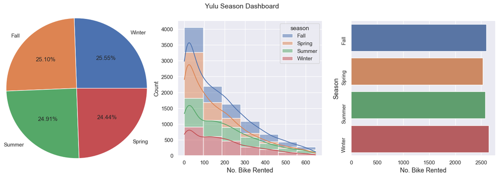

```python
plt.figure(figsize=(18, 5)).suptitle(
    "Yulu Season Dashboard", fontsize=14)

plt.subplot(1, 3, 1)
plt.pie(df_yulu['season'].value_counts().values, labels=df_yulu['season'].value_counts(
).index, radius=1.3, autopct='%1.2f%%',)  # type: ignore

plt.subplot(1, 3, 2)
sns.histplot(data=df_yulu, x='count', bins=7,
             hue='season', kde=True, multiple="stack")
plt.xlabel('No. Bike Rented', fontsize=13)
plt.ylabel("Count", fontsize=12)

plt.subplot(1, 3, 3)
sns.countplot(df_yulu, y='season')
plt.xlabel("No. Bike Rented", fontsize=13)
plt.ylabel('Season', fontsize=13)
plt.xticks(rotation=0, fontsize=11)
plt.yticks(rotation=90, fontsize=11)

plt.show()
```

### **Holiday**

```python
df_yulu['holiday'].unique()
```

```
['No', 'Yes']
Categories (2, object): ['No', 'Yes']
```

```python
df_yulu['holiday'].value_counts()
```

```
No     10049
Yes      303
Name: holiday, dtype: int64
```

```python
df_yulu['holiday'].value_counts(normalize=True)*100
```

```
No     97.073029
Yes     2.926971
Name: holiday, dtype: float64
```

#### **Statitical Analysis**

```python
df_yulu['holiday'].describe()
```

```
count     10352
unique        2
top          No
freq      10049
Name: holiday, dtype: object
```

```python
df_yulu['holiday'].mode()[0]
```

```
'No'
```

```python
df_yulu.groupby('holiday')["count"].describe()
```

| holiday | count | mean | std | min | 25% | 50% | 75% | max |
| --- | --- | --- | --- | --- | --- | --- | --- | --- |
| No | 10049.0 | 176.178426 | 156.702198 | 1.0 | 40.0 | 139.0 | 270.0 | 649.0 |
| Yes | 303.0 | 182.613861 | 165.174199 | 1.0 | 36.5 | 126.0 | 308.0 | 597.0 |

#### **Plot the Graph**

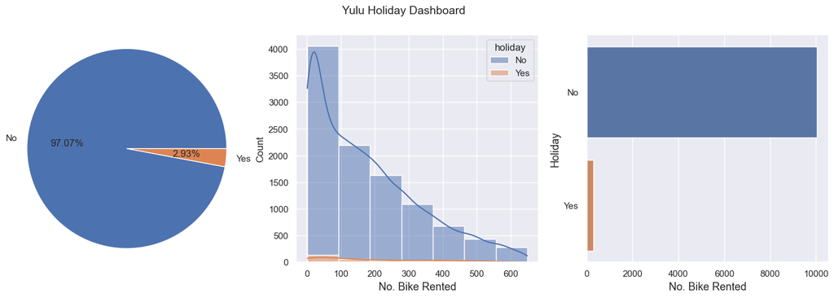

```python
plt.figure(figsize=(18, 5)).suptitle(
    "Yulu Holiday Dashboard", fontsize=14)

plt.subplot(1, 3, 1)
plt.pie(df_yulu['holiday'].value_counts().values, labels=df_yulu['holiday'].value_counts(
).index, radius=1.1, autopct='%1.2f%%',)  # type: ignore

plt.subplot(1, 3, 2)
sns.histplot(data=df_yulu, x='count', bins=7,
             hue='holiday', kde=True, multiple="stack")
plt.xlabel('No. Bike Rented', fontsize=13)
plt.ylabel("Count", fontsize=12)

plt.subplot(1, 3, 3)
sns.countplot(df_yulu, y='holiday')
plt.xlabel("No. Bike Rented", fontsize=13)
plt.ylabel('Holiday', fontsize=13)
plt.xticks(rotation=0, fontsize=11)
plt.yticks(rotation=0, fontsize=11)

plt.show()
```

### **Working Day**

```python
df_yulu['workingday'].unique()
```

```
['No', 'Yes']
Categories (2, object): ['No', 'Yes']
```

```python
df_yulu['workingday'].value_counts()
```

```
Yes    6992
No     3360
Name: workingday, dtype: int64
```

```python
df_yulu['workingday'].value_counts(normalize=True)*100
```

```
Yes    67.542504
No     32.457496
Name: workingday, dtype: float64
```

#### **Statitical Analysis**

```python
df_yulu['workingday'].describe()
```

```
count     10352
unique        2
top         Yes
freq       6992
Name: workingday, dtype: object
```

```python
df_yulu['workingday'].mode()[0]
```

```
'Yes'
```

```python
df_yulu.groupby('workingday')["count"].describe()
```

| workingday | count | mean | std | min | 25% | 50% | 75% | max |
| --- | --- | --- | --- | --- | --- | --- | --- | --- |
| No | 3360.0 | 182.189881 | 165.030731 | 1.0 | 43.0 | 125.0 | 297.0 | 648.0 |
| Yes | 6992.0 | 173.568507 | 152.851331 | 1.0 | 38.0 | 144.0 | 263.0 | 649.0 |

#### **Plot the Graph**

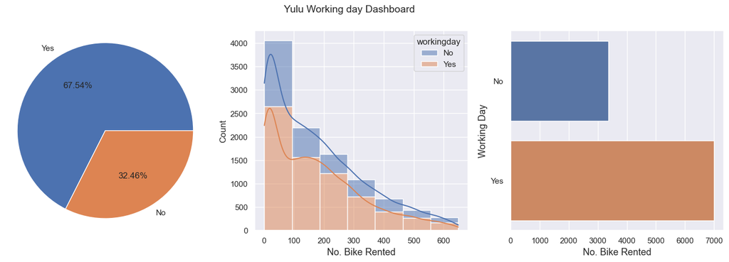

```python
plt.figure(figsize=(18, 5)).suptitle(
    "Yulu Working day Dashboard", fontsize=14)

plt.subplot(1, 3, 1)
plt.pie(df_yulu['workingday'].value_counts().values, labels=df_yulu['workingday'].value_counts(
).index, radius=1.1, autopct='%1.2f%%',)  # type: ignore

plt.subplot(1, 3, 2)
sns.histplot(data=df_yulu, x='count', bins=7,
             hue='workingday', kde=True, multiple="stack")
plt.xlabel('No. Bike Rented', fontsize=13)
plt.ylabel("Count", fontsize=12)

plt.subplot(1, 3, 3)
sns.countplot(df_yulu, y='workingday')
plt.xlabel("No. Bike Rented", fontsize=13)
plt.ylabel('Working Day', fontsize=13)
plt.xticks(rotation=0, fontsize=11)
plt.yticks(rotation=0, fontsize=11)

plt.show()
```

### **Weather**

```python
df_yulu['weather'].unique()
```

```
['Clear or Cloudy', 'Mist', 'Light Rain or Snow', 'Heavy Rain or Snow']
Categories (4, object): ['Clear or Cloudy', 'Heavy Rain or Snow', 'Light Rain or Snow', 'Mist']
```

```python
df_yulu['weather'].value_counts()
```

```
Clear or Cloudy       6821
Mist                  2733
Light Rain or Snow     797
Heavy Rain or Snow       1
Name: weather, dtype: int64
```

```python
df_yulu['weather'].value_counts(normalize=True)*100
```

```
Clear or Cloudy       65.890649
Mist                  26.400696
Light Rain or Snow     7.698995
Heavy Rain or Snow     0.009660
Name: weather, dtype: float64
```

#### **Statitical Analysis**

```python
df_yulu['weather'].describe()
```

```
count               10352
unique                  4
top       Clear or Cloudy
freq                 6821
Name: weather, dtype: object
```

```python
df_yulu['weather'].mode()[0]
```

```
'Clear or Cloudy'
```

```python
df_yulu.groupby('weather')["count"].describe()
```

| weather | count | mean | std | min | 25% | 50% | 75% | max |
| --- | --- | --- | --- | --- | --- | --- | --- | --- |
| Clear or Cloudy | 6821.0 | 187.822607 | 162.329150 | 1.0 | 44.0 | 153.0 | 288.0 | 649.0 |
| Heavy Rain or Snow | 1.0 | 164.000000 | NaN | 164.0 | 164.0 | 164.0 | 164.0 | 164.0 |
| Light Rain or Snow | 797.0 | 113.562108 | 121.648539 | 1.0 | 24.0 | 73.0 | 158.0 | 646.0 |
| Mist | 2733.0 | 166.095134 | 147.163209 | 1.0 | 39.0 | 130.0 | 254.0 | 648.0 |

#### **Plot the Graph**

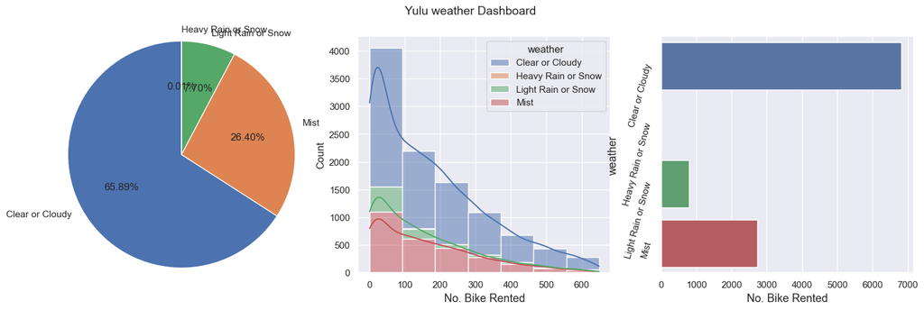

```python
plt.figure(figsize=(18, 5)).suptitle(
    "Yulu weather Dashboard", fontsize=14)

plt.subplot(1, 3, 1)
plt.pie(df_yulu['weather'].value_counts().values, labels=df_yulu['weather'].value_counts(
).index, radius=1.2, autopct='%1.2f%%', rotatelabels=False, startangle=90, counterclock=True)  # type: ignore

plt.subplot(1, 3, 2)
sns.histplot(data=df_yulu, x='count', bins=7,
             hue='weather', kde=True, multiple="stack")
plt.xlabel('No. Bike Rented', fontsize=13)
plt.ylabel("Count", fontsize=12)

plt.subplot(1, 3, 3)
sns.countplot(df_yulu, y='weather')
plt.xlabel("No. Bike Rented", fontsize=13)
plt.ylabel('weather', fontsize=13)
plt.xticks(rotation=0, fontsize=11)
plt.yticks(rotation=75, fontsize=11)

plt.show()
```

### **Temperatue**

```python
df_yulu['temp'].unique().shape
```

```
(49,)
```

```python
df_yulu['temp'].value_counts().head(5)
```

```
14.76    452
26.24    425
28.70    400
13.94    393
18.86    389
Name: temp, dtype: int64
```

```python
df_yulu['temp'].value_counts(normalize=True).head(5)*100
```

```
14.76    4.366306
26.24    4.105487
28.70    3.863988
13.94    3.796368
18.86    3.757728
Name: temp, dtype: float64
```

#### **Statitical Analysis**

```python
df_yulu['temp'].describe()
```

```
count    10352.000000
mean        20.114397
std          7.784824
min          0.820000
25%         13.940000
50%         20.500000
75%         26.240000
max         41.000000
Name: temp, dtype: float64
```

```python
df_yulu['temp'].mean()
```

```
20.1143972179289
```

```python
df_yulu['temp'].median()
```

```
20.5
```

```python
df_yulu_grouped['temp_group'].mode()[0]
```

```
'25.1 to 30.0'
```

#### **Plot the Graph**

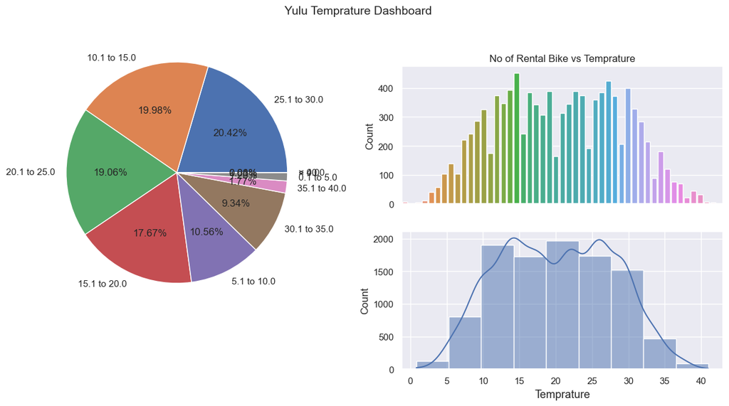

```python
plt.figure(figsize=(15, 10)).suptitle("Yulu Temprature Dashboard", fontsize=14)

plt.subplot(2, 2, 1)
plt.pie(df_yulu_grouped['temp_group'].value_counts().values, labels=df_yulu_grouped['temp_group'].value_counts(
).index, radius=1.3, autopct='%1.2f%%')  # type: ignore

plt.subplot(3, 2, 2)
sns.countplot(df_yulu, x='temp')
plt.title('No of Rental Bike vs Temprature', fontsize=12)
plt.ylabel('Count', fontsize=12)
plt.xlabel('', fontsize=11)
plt.xticks([], fontsize=11)
plt.yticks(rotation=0, fontsize=11)

plt.subplot(3, 2, 4)
# sns.countplot(df_yulu_grouped, x='temp_group')
# plt.ylabel('Count', fontsize=12)
# plt.xlabel('', fontsize=11)
# plt.xticks(rotation=30, fontsize=11)
# plt.yticks(rotation=0, fontsize=11)

sns.histplot(data=df_yulu, x='temp', bins=9, kde=True, multiple="stack")
plt.xlabel('Temprature', fontsize=13)
plt.ylabel("Count", fontsize=12)

plt.show()
```

### **Feeling Temperature**

```python
df_yulu['atemp'].unique().shape
```

```
(60,)
```

```python
df_yulu['atemp'].value_counts().head(5)
```

```
31.060    607
25.760    409
22.725    389
20.455    385
16.665    375
Name: atemp, dtype: int64
```

```python
df_yulu['atemp'].value_counts(normalize=True).head(5)*100
```

```
31.060    5.863601
25.760    3.950927
22.725    3.757728
20.455    3.719088
16.665    3.622488
Name: atemp, dtype: float64
```

#### **Statitical Analysis**

```python
df_yulu['atemp'].describe()
```

```
count    10352.000000
mean        23.551453
std          8.443686
min          0.760000
25%         16.665000
50%         24.240000
75%         31.060000
max         45.455000
Name: atemp, dtype: float64
```

```python
df_yulu['atemp'].mean()
```

```
23.551453342349305
```

```python
df_yulu['atemp'].median()
```

```
24.24
```

```python
df_yulu_grouped['atemp_group'].mode()[0]
```

```
'30.1 to 35.0'
```

#### **Plot the Graph**

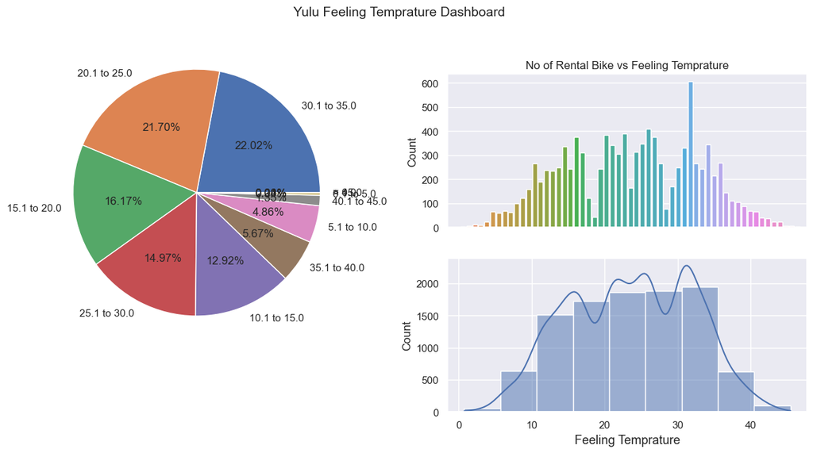

```python
plt.figure(figsize=(15, 10)).suptitle(
    "Yulu Feeling Temprature Dashboard", fontsize=14)

plt.subplot(2, 2, 1)
plt.pie(df_yulu_grouped['atemp_group'].value_counts().values, labels=df_yulu_grouped['atemp_group'].value_counts(
).index, radius=1.3, autopct='%1.2f%%')  # type: ignore

plt.subplot(3, 2, 2)
sns.countplot(df_yulu, x='atemp')
plt.title('No of Rental Bike vs Feeling Temprature', fontsize=12)
plt.ylabel('Count', fontsize=12)
plt.xlabel('', fontsize=11)
plt.xticks([], fontsize=11)
plt.yticks(rotation=0, fontsize=11)

plt.subplot(3, 2, 4)
# sns.countplot(df_yulu_grouped, x='atemp_group')
# plt.ylabel('Count', fontsize=12)
# plt.xlabel('', fontsize=11)
# plt.xticks(rotation=30, fontsize=10)
# plt.yticks(rotation=0, fontsize=11)

sns.histplot(data=df_yulu, x='atemp', bins=9, kde=True, multiple="stack")
plt.xlabel('Feeling Temprature', fontsize=13)
plt.ylabel("Count", fontsize=12)

plt.show()
```

### **Humidity**

```python
df_yulu['humidity'].unique().shape
```

```
(87,)
```

```python
df_yulu['humidity'].value_counts().head(5)
```

```
88    354
94    320
83    309
87    283
70    250
Name: humidity, dtype: int64
```

```python
df_yulu['humidity'].value_counts(normalize=True).head(5)*100
```

```
88    3.419629
94    3.091190
83    2.984930
87    2.733771
70    2.414992
Name: humidity, dtype: float64
```

#### **Statitical Analysis**

```python
df_yulu['humidity'].describe()
```

```
count    10352.000000
mean        62.623454
std         18.869422
min          8.000000
25%         48.000000
50%         62.000000
75%         78.000000
max        100.000000
Name: humidity, dtype: float64
```

```python
df_yulu['humidity'].mean()
```

```
62.6234544049459
```

```python
df_yulu['humidity'].median()
```

```
62.0
```

```python
df_yulu_grouped['humidity_group'].mode()[0]
```

```
'60.1-70.0 %'
```

#### **Plot the Graph**

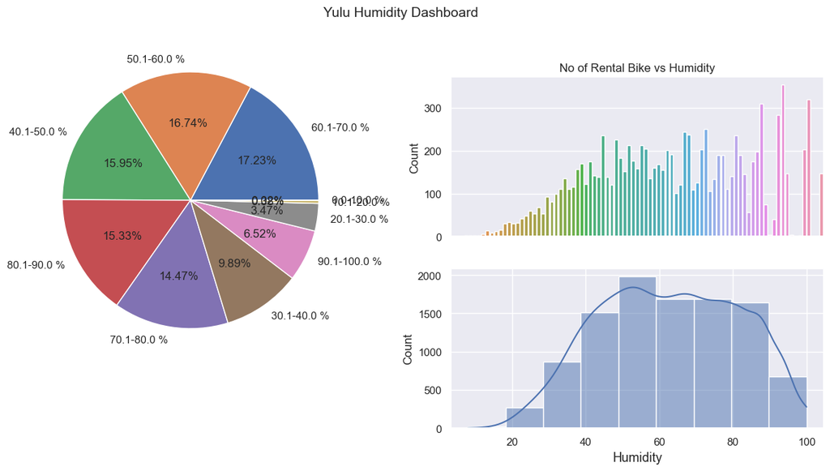

```python
plt.figure(figsize=(15, 10)).suptitle("Yulu Humidity Dashboard", fontsize=14)

plt.subplot(2, 2, 1)
plt.pie(df_yulu_grouped['humidity_group'].value_counts().values, labels=df_yulu_grouped['humidity_group'].value_counts(
).index, radius=1.3, autopct='%1.2f%%')  # type: ignore

plt.subplot(3, 2, 2)
sns.countplot(df_yulu, x='humidity')
plt.title('No of Rental Bike vs Humidity', fontsize=12)
plt.ylabel('Count', fontsize=12)
plt.xlabel('', fontsize=11)
plt.xticks([], fontsize=11)
plt.yticks(rotation=0, fontsize=11)

plt.subplot(3, 2, 4)
# sns.countplot(df_yulu_grouped, x='humidity_group')
# plt.ylabel('Count', fontsize=12)
# plt.xlabel('', fontsize=11)
# plt.xticks(rotation=30, fontsize=11)
# plt.yticks(rotation=0, fontsize=11)

sns.histplot(data=df_yulu, x='humidity', bins=9, kde=True, multiple="stack")
plt.xlabel('Humidity', fontsize=13)
plt.ylabel("Count", fontsize=12)

plt.show()
```

### **Wind Speed**

```python
df_yulu['windspeed'].unique().shape
```

```
(16,)
```

```python
df_yulu['windspeed'].value_counts().head(5)
```

```
0.0000     1285
8.9981     1093
11.0014    1019
12.9980    1013
7.0015     1009
Name: windspeed, dtype: int64
```

```python
df_yulu['windspeed'].value_counts(normalize=True).head(5)*100
```

```
0.0000     12.413060
8.9981     10.558346
11.0014     9.843509
12.9980     9.785549
7.0015      9.746909
Name: windspeed, dtype: float64
```

#### **Statitical Analysis**

```python
df_yulu['windspeed'].describe()
```

```
count    10352.000000
mean        12.267712
std          7.458563
min          0.000000
25%          7.001500
50%         11.001400
75%         16.997900
max         31.000900
Name: windspeed, dtype: float64
```

```python
df_yulu['windspeed'].mean()
```

```
12.26771164992272
```

```python
df_yulu['windspeed'].median()
```

```
11.0014
```

```python
df_yulu_grouped['windspeed_group'].mode()[0]
```

```
'10.1-20.0'
```

#### **Plot the Graph**

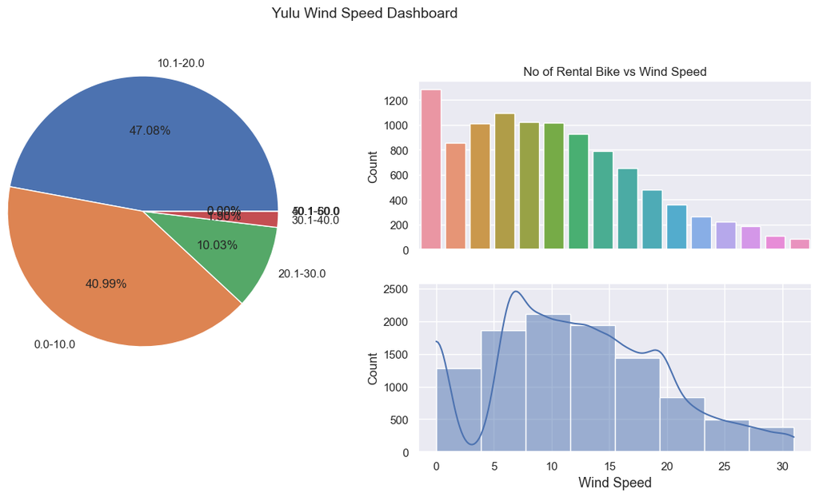

```python
plt.figure(figsize=(15, 10)).suptitle("Yulu Wind Speed Dashboard", fontsize=14)

plt.subplot(2, 2, 1)
plt.pie(df_yulu_grouped['windspeed_group'].value_counts().values, labels=df_yulu_grouped['windspeed_group'].value_counts(
).index, radius=1.3, autopct='%1.2f%%')  # type: ignore

plt.subplot(3, 2, 2)
sns.countplot(df_yulu, x='windspeed')
plt.title('No of Rental Bike vs Wind Speed', fontsize=12)
plt.ylabel('Count', fontsize=12)
plt.xlabel('', fontsize=11)
plt.xticks([], fontsize=11)
plt.yticks(rotation=0, fontsize=11)

plt.subplot(3, 2, 4)
# sns.countplot(df_yulu_grouped, x='windspeed_group')
# plt.ylabel('Count', fontsize=12)
# plt.xlabel('', fontsize=11)
# plt.xticks(rotation=30, fontsize=11)
# plt.yticks(rotation=0, fontsize=11)

sns.histplot(data=df_yulu, x='windspeed', bins=8, kde=True, multiple="stack")
plt.xlabel('Wind Speed', fontsize=13)
plt.ylabel("Count", fontsize=12)

plt.show()
```

### **Bike Rent by Casual user**

```python
df_yulu['casual'].unique().shape
```

```
(285,)
```

```python
df_yulu['casual'].value_counts().head(5)
```

```
0    961
1    645
2    475
3    433
4    343
Name: casual, dtype: int64
```

```python
df_yulu['casual'].value_counts(normalize=True).head(5)*100
```

```
0    9.283230
1    6.230680
2    4.588485
3    4.182767
4    3.313369
Name: casual, dtype: float64
```

#### **Statitical Analysis**

```python
df_yulu['casual'].describe()
```

```
count    10352.000000
mean        34.136785
std         47.224470
min          0.000000
25%          4.000000
50%         16.000000
75%         46.000000
max        355.000000
Name: casual, dtype: float64
```

```python
df_yulu['casual'].mean()
```

```
34.13678516228748
```

```python
df_yulu['casual'].median()
```

```
16.0
```

```python
df_yulu_grouped['casual_group'].mode()[0]
```

```
'0-100'
```

#### **Check for Outliers**

```python
check_outlier(df_yulu, 'casual')['upper']
```

```
{'list': 1173     144
 1174     149
 1175     124
 1311     126
 1312     174
         ...
 10610    122
 10611    148
 10612    164
 10613    167
 10614    139
 Name: casual, Length: 740, dtype: int64,
 'length': 740}
```

```python
check_outlier(df_yulu, 'casual')['lower']
```

```
{'list': Series([], Name: casual, dtype: int64), 'length': 0}
```

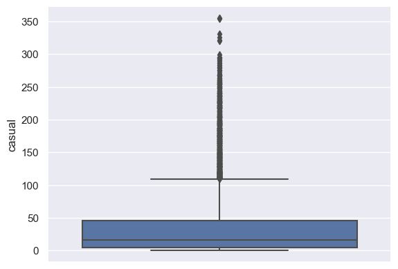

```python
sns.boxplot(df_yulu, y='casual')
```

#### **Plot the Graph**

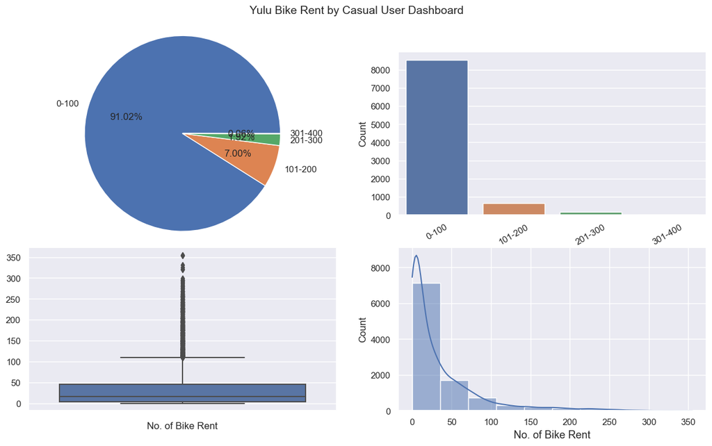

```python
plt.figure(figsize=(15, 8)).suptitle(
    "Yulu Bike Rent by Casual User Dashboard", fontsize=14)

plt.subplot(2, 2, 1)
plt.pie(df_yulu_grouped['casual_group'].value_counts().values, labels=df_yulu_grouped['casual_group'].value_counts(
).index, radius=1.5, autopct='%1.2f%%')  # type: ignore

plt.subplot(2, 2, 3)
sns.boxplot(df_yulu, y="casual")
plt.xlabel('No. of Bike Rent', fontsize=12)
plt.ylabel('')

plt.subplot(2, 2, 2)
sns.countplot(df_yulu_grouped, x='casual_group')
plt.ylabel('Count', fontsize=12)
plt.xlabel('', fontsize=11)
plt.xticks(rotation=30, fontsize=11)
plt.yticks(fontsize=11)

plt.subplot(2, 2, 4)
sns.histplot(data=df_yulu, x='casual', bins=10, kde=True, multiple="stack")
plt.xlabel('No. of Bike Rent', fontsize=13)
plt.ylabel("Count", fontsize=12)

plt.show()
```

### **Bike Rent by Registered Users**

```python
df_yulu['registered'].unique().shape
```

```
(586,)
```

```python
df_yulu['registered'].value_counts().head(5)
```

```
3    194
4    190
5    173
6    152
2    144
Name: registered, dtype: int64
```

```python
df_yulu['registered'].value_counts(normalize=True).head(5)*100
```

```
3    1.874034
4    1.835394
5    1.671175
6    1.468315
2    1.391036
Name: registered, dtype: float64
```

#### **Statitical Analysis**

```python
df_yulu['registered'].describe()
```

```
count    10352.000000
mean       142.230004
std        127.388471
min          0.000000
25%         34.000000
50%        114.000000
75%        212.000000
max        629.000000
Name: registered, dtype: float64
```

```python
df_yulu['registered'].mean()
```

```
142.23000386398763
```

```python
df_yulu['registered'].median()
```

```
114.0
```

```python
df_yulu_grouped['registered_group'].mode()[0]
```

```
'0-100'
```

#### **Check for Outliers**

```python
check_outlier(df_yulu, 'registered')['upper']
```

```
{'list': 1844     485
 1987     539
 2011     532
 2012     480
 2059     540
         ...
 10832    493
 10855    533
 10856    512
 10879    536
 10880    546
 Name: registered, Length: 231, dtype: int64,
 'length': 231}
```

```python
check_outlier(df_yulu, 'registered')['lower']
```

```
{'list': Series([], Name: registered, dtype: int64), 'length': 0}
```

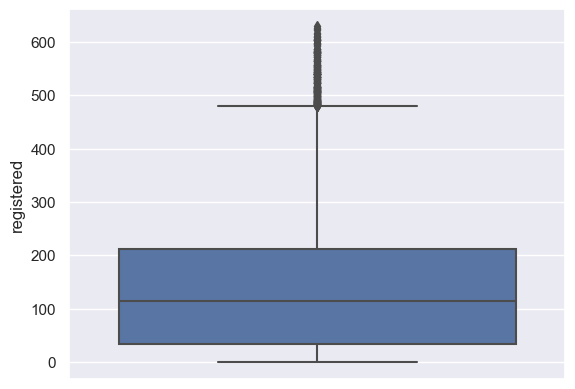

```python
sns.boxplot(df_yulu, y='registered')
```

#### **Plot the Graph**

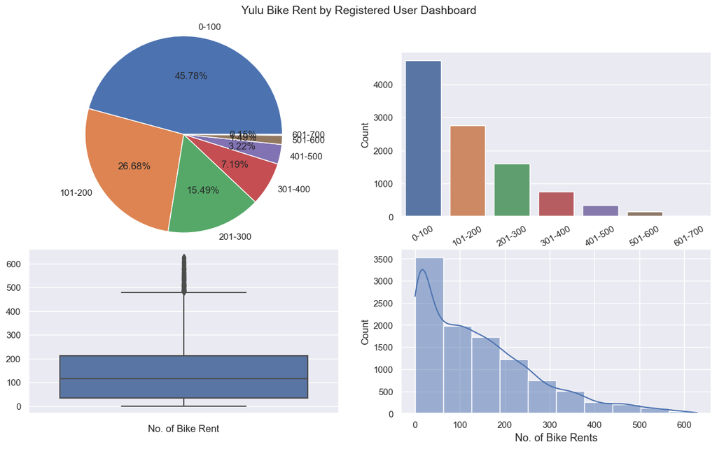

```python
plt.figure(figsize=(15, 8)).suptitle(
    "Yulu Bike Rent by Registered User Dashboard", fontsize=14)

plt.subplot(2, 2, 1)
plt.pie(df_yulu_grouped['registered_group'].value_counts().values, labels=df_yulu_grouped['registered_group'].value_counts(
).index, radius=1.5, autopct='%1.2f%%')  # type: ignore

plt.subplot(2, 2, 3)
sns.boxplot(df_yulu, y="registered")
plt.xlabel('No. of Bike Rent', fontsize=12)
plt.ylabel('')

plt.subplot(2, 2, 2)
sns.countplot(df_yulu_grouped, x='registered_group')
plt.ylabel('Count', fontsize=12)
plt.xlabel('', fontsize=11)
plt.xticks(rotation=30, fontsize=11)
plt.yticks(fontsize=11)

plt.subplot(2, 2, 4)
sns.histplot(data=df_yulu, x='registered', bins=10, kde=True, multiple="stack")
plt.xlabel('No. of Bike Rents', fontsize=13)
plt.ylabel("Count", fontsize=12)

plt.show()
```

### **Total Rental Bike Count**

```python
df_yulu['count'].unique().shape
```

```
(643,)
```

```python
df_yulu['count'].value_counts().head(5)
```

```
5    166
4    147
3    140
6    134
2    129
Name: count, dtype: int64
```

```python
df_yulu['count'].value_counts(normalize=True).head(5)*100
```

```
5    1.603555
4    1.420015
3    1.352396
6    1.294436
2    1.246136
Name: count, dtype: float64
```

#### **Statitical Analysis**

```python
df_yulu['count'].describe()
```

```
count    10352.000000
mean       176.366789
std        156.952045
min          1.000000
25%         40.000000
50%        139.000000
75%        271.000000
max        649.000000
Name: count, dtype: float64
```

```python
df_yulu['count'].mean()
```

```
176.36678902627511
```

```python
df_yulu['count'].median()
```

```
139.0
```

```python
df_yulu_grouped['count_group'].mode()[0]
```

```
'0-100'
```

#### **Check for Outliers**

```python
check_outlier(df_yulu, 'count')['upper']
```

```
{'list': 2587     638
 3619     628
 4456     620
 4480     625
 6610     644
         ...
 10204    627
 10318    646
 10423    619
 10750    636
 10759    622
 Name: count, Length: 77, dtype: int64,
 'length': 77}
```

```python
check_outlier(df_yulu, 'count')['lower']
```

```
{'list': Series([], Name: count, dtype: int64), 'length': 0}
```

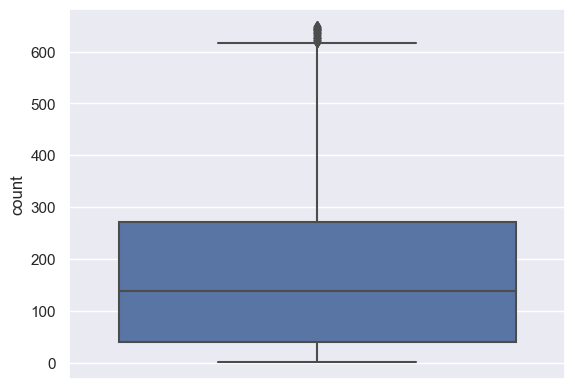

```python
sns.boxplot(df_yulu, y='count')
```

#### **Plot the Graph**

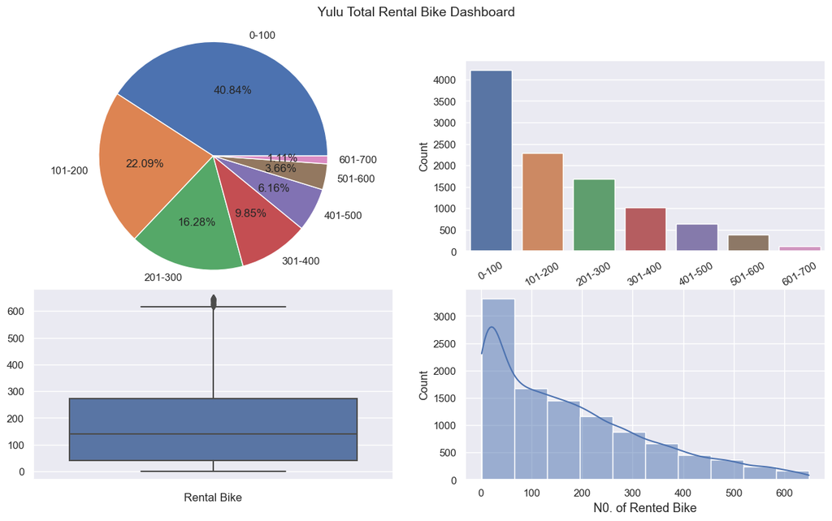

```python
plt.figure(figsize=(15, 8)).suptitle(
    "Yulu Total Rental Bike Dashboard", fontsize=14)

plt.subplot(2, 2, 1)
plt.pie(df_yulu_grouped['count_group'].value_counts().values, labels=df_yulu_grouped['count_group'].value_counts(
).index, radius=1.5, autopct='%1.2f%%')  # type: ignore

plt.subplot(2, 2, 3)
sns.boxplot(df_yulu, y="count")
plt.xlabel('Rental Bike', fontsize=12)
plt.ylabel('')

plt.subplot(2, 2, 2)
sns.countplot(df_yulu_grouped, x='count_group')
plt.ylabel('Count', fontsize=12)
plt.xlabel('', fontsize=11)
plt.xticks(rotation=30, fontsize=11)
plt.yticks(fontsize=11)

plt.subplot(2, 2, 4)
sns.histplot(data=df_yulu, x='count', bins=10, kde=True, multiple="stack")
plt.xlabel('N0. of Rented Bike', fontsize=13)
plt.ylabel("Count", fontsize=12)

plt.show()
```

## **Relation Between Indipendent Variable**

```python
df_yulu.columns
```

```
Index(['datetime', 'time_slot', 'season', 'holiday', 'workingday', 'weather',
       'temp', 'atemp', 'humidity', 'windspeed', 'casual', 'registered',
       'count'],
      dtype='object')
```

```python
dependent_variables = ['count']
independent_variables = ['workingday, weather, season']
```

### **Relation Between Wether & Season**

```python
Ho = "There is no relation between Weather & Season"
Ha = "Weather & Season are co-related"
```

```python
stats, p_value, dof, data = chi2_contingency(
    pd.crosstab(df_yulu['weather'], df_yulu['season'],))
stats, p_value
```

```
(50.437100227285605, 8.913970213670006e-08)
```

```python
print(Ha if (p_value < significance_level) else Ho)
```

```
Weather & Season are co-related
```

### **Relation Between Wether & Working Day**

```python
Ho = "There is no relation between Weather & Working Day"
Ha = "Weather & Working Day are co-related"
```

```python
stats, p_value, dof, data = chi2_contingency(
    pd.crosstab(df_yulu['weather'], df_yulu['workingday'],))
stats, p_value
```

```
(14.81140809965818, 0.001985116190288393)
```

```python
print(Ha if (p_value < significance_level) else Ho)
```

```
Weather & Working Day are co-related
```

### **Relation Between Working Day & Season**

```python
Ho = "There is no relation between Working Day & Season"
Ha = "Working Day & Season are co-related"
```

```python
stats, p_value, dof, data = chi2_contingency(
    pd.crosstab(df_yulu['workingday'], df_yulu['season'],))
stats, p_value
```

```
(2.1088184699125585, 0.5501307880329931)
```

```python
print(Ha if (p_value < significance_level) else Ho)
```

```
There is no relation between Working Day & Season
```

## **Bootstraping:**

```python
def filter_col_as_array(df, col, match, result_col, inverse=False):
    if inverse:
        return df[df[col] != match][result_col]
    else:
        return df[df[col] == match][result_col]
```

```python
class CLT_Interval:
    def __init__(self, mean, std_error, z_critical, margin_of_error, confidence_interval_lower, confidence_interval_upper, sample_df, significance_level, samples_size):
        self.mean = mean
        self.std_error = std_error
        self.z_critical = z_critical
        self.margin_of_error = margin_of_error
        self.confidence_interval_lower = confidence_interval_lower
        self.confidence_interval_upper = confidence_interval_upper
        self.sample_df = sample_df
        self.significance_level = significance_level
        self.samples_size = samples_size
```

```python
def bootstraping(df, samples, cl, plot=True):
    bootstrap_sample_means = []

    for _ in range(samples):
        bootstrap_sample = df.sample(n=len(df), replace=True)
        bootstrap_sample_mean = bootstrap_sample.mean()
        bootstrap_sample_means.append(bootstrap_sample_mean)

    bootstrap_mean = np.mean(bootstrap_sample_means)
    bootstrap_std_error = np.std(bootstrap_sample_means)

    z_critical = norm.ppf((1 + cl) / 2)

    # Calculate the margin of error
    margin_of_error = z_critical * bootstrap_std_error

    # Calculate the confidence interval
    confidence_interval_lower = bootstrap_mean - margin_of_error
    confidence_interval_upper = bootstrap_mean + margin_of_error

    if (plot):
        plt.figure(figsize=(8, 4))
        sns.histplot(data=bootstrap_sample_means, bins=20,
                     color='#66a3ff', label='Sample Mean', kde=True)
        plt.axvline(bootstrap_mean, color='#ff0066',
                    linestyle='dashed', linewidth=2, label='Mean')
        plt.axvline(confidence_interval_lower, color='#ff8533',
                    linestyle='dotted', linewidth=2, label='CI Lower')
        plt.axvline(confidence_interval_upper, color='#ff8533',
                    linestyle='dotted', linewidth=2, label='CI Upper')
        plt.annotate(f'Mean: {bootstrap_mean:.2f}', rotation='vertical', xy=(
            bootstrap_mean, 0), xytext=(-20, 30), textcoords='offset points', color='blacK', fontsize=15)
        plt.annotate(f'{confidence_interval_lower:.2f}', rotation='vertical', xy=(
            confidence_interval_lower, 0), xytext=(-20, 80), textcoords='offset points', color='blacK', fontsize=14)
        plt.annotate(f'{confidence_interval_upper:.2f}', rotation='vertical', xy=(
            confidence_interval_upper, 0), xytext=(10, 80), textcoords='offset points', color='blacK', fontsize=14)
        plt.legend()

    return CLT_Interval(bootstrap_mean, bootstrap_std_error, z_critical, margin_of_error, confidence_interval_lower, confidence_interval_upper, bootstrap_sample_means, cl, samples)
```

```
Bootstrap Mean: 176.34169300618237
Bootstrap Standard Error: 1.5393571100012733
Z-Critical Value: 2.5758293035489004
Margin of Error: 3.9651211525676278
Bootstrap Confidence Interval: (172.37657185361473, 180.30681415875)
```

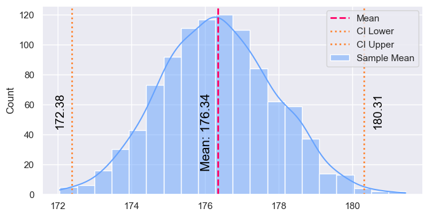

```python
df = df_yulu['count']
samples = 1000
confidence_level = 0.99
clt_interval = bootstraping(df, samples, cl=confidence_level, plot=True)

print("Bootstrap Mean:", clt_interval.mean)
print("Bootstrap Standard Error:", clt_interval.std_error)
print("Z-Critical Value:", clt_interval.z_critical)
print("Margin of Error:", clt_interval.margin_of_error)
print("Bootstrap Confidence Interval:",
      (clt_interval.confidence_interval_lower, clt_interval.confidence_interval_upper))
```

## **Questions**

- Working Day has effect on number of electric cycles rented
- No. of cycles rented similar or different in different seasons
- No. of cycles rented similar or different in different weather
- Weather is dependent on season (check between 2 predictor variable)

### Validate Target variable's Data is `Gaussian or not`

```python
stats, p_value = shapiro(df_yulu['count'])
round(p_value, 4)
```

```
0.0
```

```python
"Data is not Gaussian" if (
    p_value < significance_level) else "Data is Gaussian"
```

```
'Data is not Gaussian'
```

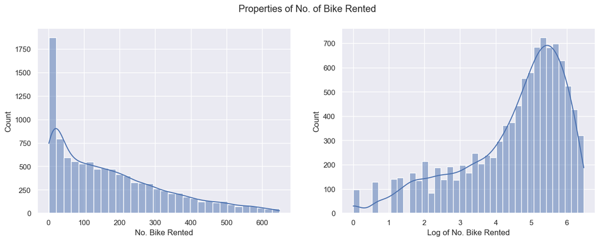

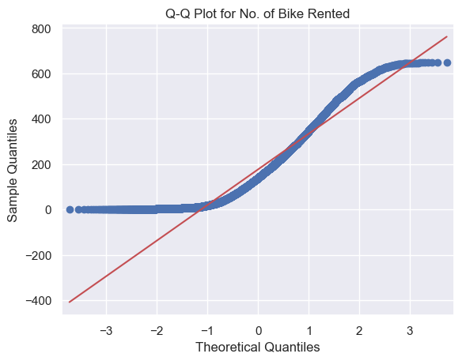

```python
plt.figure(figsize=(15, 5)).suptitle(
    "Properties of No. of Bike Rented")

plt.subplot(121)
sns.histplot(df_yulu['count'], kde=True)
plt.ylabel("Count")
plt.xlabel("No. Bike Rented")

plt.subplot(122)
sns.histplot(np.log(df_yulu['count']), kde=True)
plt.ylabel("Count")
plt.xlabel("Log of No. Bike Rented")

qqplot(df_yulu['count'], line='s')
plt.title("Q-Q Plot for No. of Bike Rented")

plt.show()
```

### **Q1. Working Day has effect on number of electric cycles rented**

```python
rented_bike_on_Working_day = df_yulu.groupby(
    'workingday').aggregate(
        mean=('count', 'mean'),
        count=('count', 'count')).reset_index()
rented_bike_on_Working_day
```

|  | workingday | mean | count |
| --- | --- | --- | --- |
| 0 | No | 182.189881 | 3360 |
| 1 | Yes | 173.568507 | 6992 |

```python
rent_on_wd = filter_col_as_array(
    df=df_yulu, col='workingday', match='Yes', result_col='count')
rent_on_non_wd = filter_col_as_array(
    df=df_yulu, col='workingday', match='No', result_col='count')
```

#### **Plot the Graph to Support Assumptions**

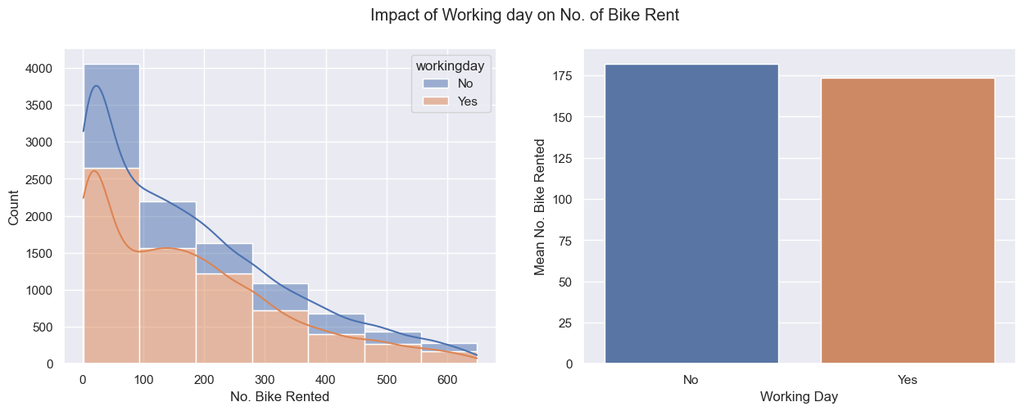

```python
plt.figure(figsize=(15, 5)).suptitle(
    "Impact of Working day on No. of Bike Rent")

plt.subplot(121)
sns.histplot(data=df_yulu, x='count', bins=7,
             hue='workingday', kde=True, multiple="stack")
plt.ylabel("Count")
plt.xlabel("No. Bike Rented")

plt.subplot(122)
sns.barplot(x=rented_bike_on_Working_day['workingday'],
            y=rented_bike_on_Working_day['mean'])
plt.ylabel("Mean No. Bike Rented")
plt.xlabel("Working Day")
plt.show()
plt.show()
```

#### **Hypothesis Testing**

Here, we found that mean of Bike rented in Working day is less than non-working day.

```python
Ho = "Working Day has no effect on number of electric cycles rented"
Ha = "Working Day has effect on number of electric cycles rented"
```

##### Using `T-Test`

```python
t_statistic, p_value = ttest_ind(
    rent_on_wd, rent_on_non_wd)
round((t_statistic*100), 4), round((p_value*100), 4)
```

```
(-261.7523, 0.887)
```

```python
print(Ha if (p_value < significance_level) else Ho)
```

```
Working Day has effect on number of electric cycles rented
```

#### **Use the `Central limit theorem` to compute the interval**

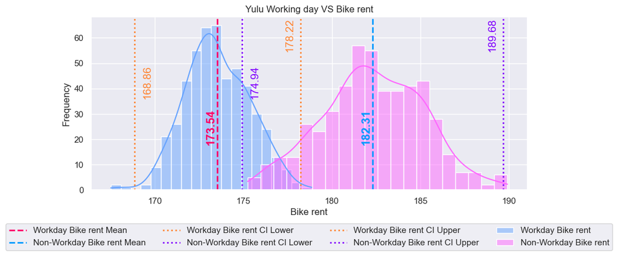

```python
samples = 500
wd_clt_interval = bootstraping(
    rent_on_wd, samples, cl=confidence_interval, plot=False)
non_wd_clt_interval = bootstraping(
    rent_on_non_wd, samples, cl=confidence_interval, plot=False)

plt.figure(figsize=(10, 4))

sns.histplot(data=wd_clt_interval.sample_df, bins=20,
             color='#66a3ff', label='Workday Bike rent', kde=True)
sns.histplot(data=non_wd_clt_interval.sample_df, bins=20,
             color='#ff66ff', label='Non-Workday Bike rent', kde=True)

plt.axvline(wd_clt_interval.mean, color='#ff0066',
            linestyle='dashed', linewidth=2, label='Workday Bike rent Mean')
plt.axvline(non_wd_clt_interval.mean, color='#0099ff',
            linestyle='dashed', linewidth=2, label='Non-Workday Bike rent Mean')

plt.annotate(f'{wd_clt_interval.mean:.2f}', rotation='vertical', xy=(
    wd_clt_interval.mean, 0), xytext=(-15, 60), textcoords='offset points', color='#ff0066', fontsize=15, weight='bold')
plt.annotate(f'{non_wd_clt_interval.mean:.2f}', rotation='vertical', xy=(
    non_wd_clt_interval.mean, 0), xytext=(-15, 60), textcoords='offset points', color='#0099ff', fontsize=15, weight='bold')

plt.axvline(wd_clt_interval.confidence_interval_lower, color='#ff8533',
            linestyle='dotted', linewidth=2, label='Workday Bike rent CI Lower')
plt.axvline(non_wd_clt_interval.confidence_interval_lower, color='#8000ff',
            linestyle='dotted', linewidth=2, label='Non-Workday Bike rent CI Lower')

plt.annotate(f'{wd_clt_interval.confidence_interval_lower:.2f}', rotation='vertical', xy=(
    wd_clt_interval.confidence_interval_lower, 0), xytext=(10, 120), textcoords='offset points', color='#ff8533', fontsize=14)
plt.annotate(f'{non_wd_clt_interval.confidence_interval_lower:.2f}', rotation='vertical', xy=(
    non_wd_clt_interval.confidence_interval_lower, 0), xytext=(10, 120), textcoords='offset points', color='#8000ff', fontsize=14)

plt.axvline(wd_clt_interval.confidence_interval_upper, color='#ff8533',
            linestyle='dotted', linewidth=2, label='Workday Bike rent CI Upper')
plt.axvline(non_wd_clt_interval.confidence_interval_upper, color='#8000ff',
            linestyle='dotted', linewidth=2, label='Non-Workday Bike rent CI Upper')

plt.annotate(f'{wd_clt_interval.confidence_interval_upper:.2f}', rotation='vertical', xy=(
    wd_clt_interval.confidence_interval_upper, 0), xytext=(-20, 180), textcoords='offset points', color='#ff8533', fontsize=14)
plt.annotate(f'{non_wd_clt_interval.confidence_interval_upper:.2f}', rotation='vertical', xy=(
    non_wd_clt_interval.confidence_interval_upper, 0), xytext=(-20, 180), textcoords='offset points', color='#8000ff', fontsize=14)

plt.xlabel('Bike rent')
plt.ylabel('Frequency')
plt.title('Yulu Working day VS Bike rent')
plt.legend(bbox_to_anchor=(0.5, -0.35),
           loc='lower center', borderaxespad=0, ncol=4)


plt.show()
```

### #

> Insight

> Working Day has effect on number of electric cycles rented.

```
    Ho -> Working Day has no effect on number of electric cycles rented
    Ha -> Working Day has effect on number of electric cycles rented

Using T-Test p_value found that 0.887%.
```

- With Confidence interval of 99% & Sample Size of 500
  - Mean Bike rent on Working day is 173.48 with a Intervals of (168.92 - 178.04).
  - Mean Bike rent on Non-Working day is 182.21 with a Intervals of (175.20 - 189.22)
  - As 0.887% < 1% Thus Rejecting Ho & Accept Ha.

As per T-Test we can Conclude "Working Day has effect on number of electric cycles rented".

### **Q2. No. of cycles rented similar or different in different seasons**

```python
rented_bike_on_seasons = df_yulu.groupby(
    'season').aggregate(
        mean=('count', 'mean'),
        count=('count', 'count')).reset_index()
rented_bike_on_seasons
```

|  | season | mean | count |
| --- | --- | --- | --- |
| 0 | Fall | 210.633564 | 2598 |
| 1 | Spring | 112.774308 | 2530 |
| 2 | Summer | 195.945328 | 2579 |
| 3 | Winter | 184.446503 | 2645 |

```python
rent_on_summer = filter_col_as_array(
    df=df_yulu, col='season', match='Summer', result_col='count')
rent_on_fall = filter_col_as_array(
    df=df_yulu, col='season', match='Fall', result_col='count')
rent_on_winter = filter_col_as_array(
    df=df_yulu, col='season', match='Winter', result_col='count')
rent_on_spring = filter_col_as_array(
    df=df_yulu, col='season', match='Spring', result_col='count')
```

#### **Plot the Graph to Support Assumptions**

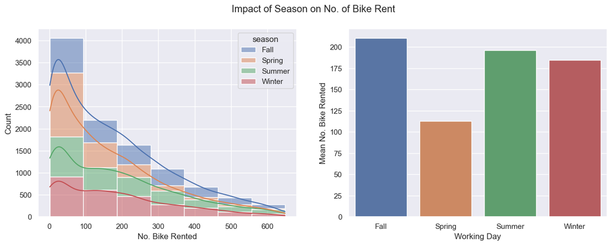

```python
plt.figure(figsize=(15, 5)).suptitle(
    "Impact of Season on No. of Bike Rent")

plt.subplot(121)
sns.histplot(data=df_yulu, x='count', bins=7,
             hue='season', kde=True, multiple="stack")
plt.ylabel("Count")
plt.xlabel("No. Bike Rented")

plt.subplot(122)
sns.barplot(x=rented_bike_on_seasons['season'],
            y=rented_bike_on_seasons['mean'])
plt.ylabel("Mean No. Bike Rented")
plt.xlabel("Working Day")
plt.show()
plt.show()
```

#### **Hypothesis Testing**

Here, we found that No. of Bike rented are different in different seasons

```python
Ho = "No. of Bike rented are Similar in different seasons"
Ha = "No. of Bike rented are different in different seasons"
```

##### Using `ANOVA`

```python
t_statistic, p_value = f_oneway(
    rent_on_summer, rent_on_fall, rent_on_winter, rent_on_spring)
round((t_statistic*100), 4), round((p_value*100), 4)
```

```
(20711.2224, 0.0)
```

```python
print(Ha if (p_value < significance_level) else Ho)
```

```
No. of Bike rented are different in different seasons
```

##### Using `Kruskal`

```python
t_statistic, p_value = kruskal(
    rent_on_summer, rent_on_fall, rent_on_winter, rent_on_spring)
round((t_statistic*100), 4), round((p_value*100), 4)
```

```
(59158.8977, 0.0)
```

```python
print(Ha if (p_value < significance_level) else Ho)
```

```
No. of Bike rented are different in different seasons
```

##### Using `Levene`

```python
t_statistic, p_value = levene(
    rent_on_summer, rent_on_fall, rent_on_winter, rent_on_spring)
round((t_statistic*100), 4), round((p_value*100), 4)
```

```
(17240.3736, 0.0)
```

```python
print(Ha if (p_value < significance_level) else Ho)
```

```
No. of Bike rented are different in different seasons
```

#### **Use the `Central limit theorem` to compute the interval**

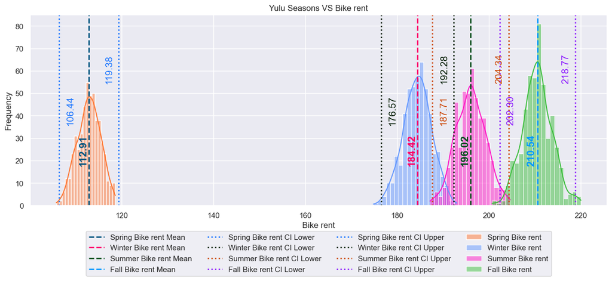

```python
samples = 500
spring_clt_interval = bootstraping(
    rent_on_spring, samples, cl=confidence_interval, plot=False)
winter_clt_interval = bootstraping(
    rent_on_winter, samples, cl=confidence_interval, plot=False)
summer_clt_interval = bootstraping(
    rent_on_summer, samples, cl=confidence_interval, plot=False)
fall_clt_interval = bootstraping(
    rent_on_fall, samples, cl=confidence_interval, plot=False)

plt.figure(figsize=(15, 5))

sns.histplot(data=spring_clt_interval.sample_df, bins=20,
             color='#ff7733', label='Spring Bike rent', kde=True)
sns.histplot(data=winter_clt_interval.sample_df, bins=20,
             color='#6699ff', label='Winter Bike rent', kde=True)
sns.histplot(data=summer_clt_interval.sample_df, bins=20,
             color='#ff1ac6', label='Summer Bike rent', kde=True)
sns.histplot(data=fall_clt_interval.sample_df, bins=20,
             color='#40bf40', label='Fall Bike rent', kde=True)

plt.axvline(spring_clt_interval.mean, color='#005580',
            linestyle='dashed', linewidth=2, label='Spring Bike rent Mean')
plt.axvline(winter_clt_interval.mean, color='#ff0066',
            linestyle='dashed', linewidth=2, label='Winter Bike rent Mean')
plt.axvline(summer_clt_interval.mean, color='#004d1a',
            linestyle='dashed', linewidth=2, label='Summer Bike rent Mean')
plt.axvline(fall_clt_interval.mean, color='#0099ff',
            linestyle='dashed', linewidth=2, label='Fall Bike rent Mean')

plt.annotate(f'{spring_clt_interval.mean:.2f}', rotation='vertical', xy=(
    spring_clt_interval.mean, 0), xytext=(-15, 60), textcoords='offset points', color='#005580', fontsize=15, weight='bold')
plt.annotate(f'{winter_clt_interval.mean:.2f}', rotation='vertical', xy=(
    winter_clt_interval.mean, 0), xytext=(-15, 60), textcoords='offset points', color='#ff0066', fontsize=15, weight='bold')
plt.annotate(f'{summer_clt_interval.mean:.2f}', rotation='vertical', xy=(
    summer_clt_interval.mean, 0), xytext=(-15, 60), textcoords='offset points', color='#004d1a', fontsize=15, weight='bold')
plt.annotate(f'{fall_clt_interval.mean:.2f}', rotation='vertical', xy=(
    fall_clt_interval.mean, 0), xytext=(-15, 60), textcoords='offset points', color='#0099ff', fontsize=15, weight='bold')

plt.axvline(spring_clt_interval.confidence_interval_lower, color='#1a75ff',
            linestyle='dotted', linewidth=2, label='Spring Bike rent CI Lower')
plt.axvline(winter_clt_interval.confidence_interval_lower, color='#001a00',
            linestyle='dotted', linewidth=2, label='Winter Bike rent CI Lower')
plt.axvline(summer_clt_interval.confidence_interval_lower, color='#cc4400',
            linestyle='dotted', linewidth=2, label='Summer Bike rent CI Lower')
plt.axvline(fall_clt_interval.confidence_interval_lower, color='#8c1aff',
            linestyle='dotted', linewidth=2, label='Fall Bike rent CI Lower')

plt.annotate(f'{spring_clt_interval.confidence_interval_lower:.2f}', rotation='vertical', xy=(
    spring_clt_interval.confidence_interval_lower, 0), xytext=(10, 120), textcoords='offset points', color='#1a75ff', fontsize=14)
plt.annotate(f'{winter_clt_interval.confidence_interval_lower:.2f}', rotation='vertical', xy=(
    winter_clt_interval.confidence_interval_lower, 0), xytext=(10, 120), textcoords='offset points', color='#001a00', fontsize=14)
plt.annotate(f'{summer_clt_interval.confidence_interval_lower:.2f}', rotation='vertical', xy=(
    summer_clt_interval.confidence_interval_lower, 0), xytext=(10, 120), textcoords='offset points', color='#cc4400', fontsize=14)
plt.annotate(f'{fall_clt_interval.confidence_interval_lower:.2f}', rotation='vertical', xy=(
    fall_clt_interval.confidence_interval_lower, 0), xytext=(10, 120), textcoords='offset points', color='#8c1aff', fontsize=14)

plt.axvline(spring_clt_interval.confidence_interval_upper, color='#1a75ff',
            linestyle='dotted', linewidth=2, label='Spring Bike rent CI Upper')
plt.axvline(winter_clt_interval.confidence_interval_upper, color='#001a00',
            linestyle='dotted', linewidth=2, label='Winter Bike rent CI Upper')
plt.axvline(summer_clt_interval.confidence_interval_upper, color='#cc4400',
            linestyle='dotted', linewidth=2, label='Summer Bike rent CI Upper')
plt.axvline(fall_clt_interval.confidence_interval_upper, color='#8c1aff',
            linestyle='dotted', linewidth=2, label='Fall Bike rent CI Upper')

plt.annotate(f'{spring_clt_interval.confidence_interval_upper:.2f}', rotation='vertical', xy=(
    spring_clt_interval.confidence_interval_upper, 0), xytext=(-20, 180), textcoords='offset points', color='#1a75ff', fontsize=14)
plt.annotate(f'{winter_clt_interval.confidence_interval_upper:.2f}', rotation='vertical', xy=(
    winter_clt_interval.confidence_interval_upper, 0), xytext=(-20, 180), textcoords='offset points', color='#001a00', fontsize=14)
plt.annotate(f'{summer_clt_interval.confidence_interval_upper:.2f}', rotation='vertical', xy=(
    summer_clt_interval.confidence_interval_upper, 0), xytext=(-20, 180), textcoords='offset points', color='#cc4400', fontsize=14)
plt.annotate(f'{fall_clt_interval.confidence_interval_upper:.2f}', rotation='vertical', xy=(
    fall_clt_interval.confidence_interval_upper, 0), xytext=(-20, 180), textcoords='offset points', color='#8c1aff', fontsize=14)

plt.xlabel('Bike rent')
plt.ylabel('Frequency')
plt.title('Yulu Seasons VS Bike rent')
plt.legend(bbox_to_anchor=(0.5, -0.37),
           loc='lower center', borderaxespad=0, ncol=4)


plt.show()
```

### #

> Insight

> No. of cycles rented similar or different in different seasons

```
    Ho -> No. of Bike rented are Similar in different seasons
    Ha -> No. of Bike rented are different in different seasons

Using ANOVA, Kruskal & Levene Test Test p_value found that 0.0%.
```

- With Confidence interval of 99% & Sample Size of 500
  - Mean Bike rent on Spring Season is 112.87 with a Intervals of (106.51 - 119.23).
  - Mean Bike rent on Winter Season is 184.68 with a Intervals of (176.95 - 192.40).
  - Mean Bike rent on Summer Season is 195.84 with a Intervals of (186.98 - 204.69).
  - Mean Bike rent on Fall Season is 210.84 with a Intervals of (202.32 - 219.37).
  - As 0% < 1% Thus Rejecting Ho & Accept Ha.

As per Anova Test we can Conclude "No. of Bike rented are different in different seasons".

### **Q3. No. of cycles rented similar or different in different weather**

```python
rented_bike_on_weather = df_yulu.groupby(
    'weather').aggregate(
        mean=('count', 'mean'),
        count=('count', 'count')).reset_index()
rented_bike_on_weather
```

|  | weather | mean | count |
| --- | --- | --- | --- |
| 0 | Clear or Cloudy | 187.822607 | 6821 |
| 1 | Heavy Rain or Snow | 164.000000 | 1 |
| 2 | Light Rain or Snow | 113.562108 | 797 |
| 3 | Mist | 166.095134 | 2733 |

```python
rent_on_clear_cloudy = filter_col_as_array(
    df=df_yulu, col='weather', match='Clear or Cloudy', result_col='count')
rent_on_heavy_rain_snow = filter_col_as_array(
    df=df_yulu, col='weather', match='Heavy Rain or Snow', result_col='count')
rent_on_light_rain_snow = filter_col_as_array(
    df=df_yulu, col='weather', match='Light Rain or Snow', result_col='count')
rent_on_mist = filter_col_as_array(
    df=df_yulu, col='weather', match='Mist', result_col='count')
```

#### **Plot the Graph to Support Assumptions**

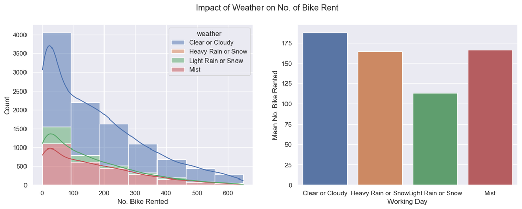

```python
plt.figure(figsize=(15, 5)).suptitle(
    "Impact of Weather on No. of Bike Rent")

plt.subplot(121)
sns.histplot(data=df_yulu, x='count', bins=7,
             hue='weather', kde=True, multiple="stack")
plt.ylabel("Count")
plt.xlabel("No. Bike Rented")

plt.subplot(122)
sns.barplot(x=rented_bike_on_weather['weather'],
            y=rented_bike_on_weather['mean'])
plt.ylabel("Mean No. Bike Rented")
plt.xlabel("Working Day")
plt.show()
plt.show()
```

#### **Hypothesis Testing**

Here, we found that No. of Bike rented are different in different weather

```python
Ho = "No. of Bike rented are Similar in different weather"
Ha = "No. of Bike rented are different in different weather"
```

##### Using `ANOVA`

```python
t_statistic, p_value = f_oneway(
    rent_on_clear_cloudy, rent_on_heavy_rain_snow, rent_on_light_rain_snow, rent_on_mist)
round((t_statistic*100), 4), round((p_value*100), 4)
```

```
(5954.9314, 0.0)
```

```python
print(Ha if (p_value < significance_level) else Ho)
```

```
No. of Bike rented are different in different weather
```

##### Using `Kruskal`

```python
t_statistic, p_value = kruskal(
    rent_on_clear_cloudy, rent_on_heavy_rain_snow, rent_on_light_rain_snow, rent_on_mist)
round((t_statistic*100), 4), round((p_value*100), 4)
```

```
(16758.251, 0.0)
```

```python
print(Ha if (p_value < significance_level) else Ho)
```

```
No. of Bike rented are different in different weather
```

##### Using `Levene`

```python
t_statistic, p_value = levene(
    rent_on_clear_cloudy, rent_on_heavy_rain_snow, rent_on_light_rain_snow, rent_on_mist)
round((t_statistic*100), 4), round((p_value*100), 4)
```

```
(5740.2193, 0.0)
```

```python
print(Ha if (p_value < significance_level) else Ho)
```

```
No. of Bike rented are different in different weather
```

#### **Use the `Central limit theorem` to compute the interval**

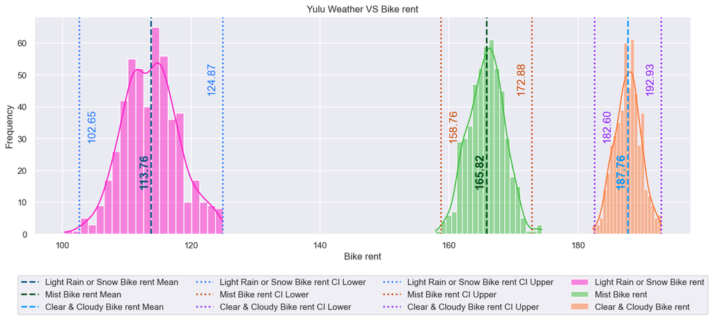

```python
samples = 500
light_rain_snow_clt_interval = bootstraping(
    rent_on_light_rain_snow, samples, cl=confidence_interval, plot=False)
# heavy_rain_snow_clt_interval = bootstraping(
#     rent_on_heavy_rain_snow, samples, cl=confidence_interval, plot=False)
mist_clt_interval = bootstraping(
    rent_on_mist, samples, cl=confidence_interval, plot=False)
clear_cloudy_clt_interval = bootstraping(
    rent_on_clear_cloudy, samples, cl=confidence_interval, plot=False)

plt.figure(figsize=(15, 5))

sns.histplot(data=light_rain_snow_clt_interval.sample_df, bins=20,
             color='#ff1ac6', label='Light Rain or Snow Bike rent', kde=True)
# sns.histplot(data=heavy_rain_snow_clt_interval.sample_df, bins=20,
#              color='#6699ff', label='Heavy Rain or Snow Bike rent', kde=True)
sns.histplot(data=mist_clt_interval.sample_df, bins=20,
             color='#40bf40', label='Mist Bike rent', kde=True)
sns.histplot(data=clear_cloudy_clt_interval.sample_df, bins=20,
             color='#ff7733', label='Clear & Cloudy Bike rent', kde=True)

plt.axvline(light_rain_snow_clt_interval.mean, color='#005580',
            linestyle='dashed', linewidth=2, label='Light Rain or Snow Bike rent Mean')
# plt.axvline(heavy_rain_snow_clt_interval.mean, color='#ff0066',
#             linestyle='dashed', linewidth=2, label='Heavy Rain or Snow Bike rent Mean')
plt.axvline(mist_clt_interval.mean, color='#004d1a',
            linestyle='dashed', linewidth=2, label='Mist Bike rent Mean')
plt.axvline(clear_cloudy_clt_interval.mean, color='#0099ff',
            linestyle='dashed', linewidth=2, label='Clear & Cloudy Bike rent Mean')

plt.annotate(f'{light_rain_snow_clt_interval.mean:.2f}', rotation='vertical', xy=(
    light_rain_snow_clt_interval.mean, 0), xytext=(-15, 60), textcoords='offset points', color='#005580', fontsize=15, weight='bold')
# plt.annotate(f'{heavy_rain_snow_clt_interval.mean:.2f}', rotation='vertical', xy=(
#     heavy_rain_snow_clt_interval.mean, 0), xytext=(-15, 60), textcoords='offset points', color='#ff0066', fontsize=15, weight='bold')
plt.annotate(f'{mist_clt_interval.mean:.2f}', rotation='vertical', xy=(
    mist_clt_interval.mean, 0), xytext=(-15, 60), textcoords='offset points', color='#004d1a', fontsize=15, weight='bold')
plt.annotate(f'{clear_cloudy_clt_interval.mean:.2f}', rotation='vertical', xy=(
    clear_cloudy_clt_interval.mean, 0), xytext=(-15, 60), textcoords='offset points', color='#0099ff', fontsize=15, weight='bold')

plt.axvline(light_rain_snow_clt_interval.confidence_interval_lower, color='#1a75ff',
            linestyle='dotted', linewidth=2, label='Light Rain or Snow Bike rent CI Lower')
# plt.axvline(heavy_rain_snow_clt_interval.confidence_interval_lower, color='#001a00',
#             linestyle='dotted', linewidth=2, label='Heavy Rain or Snow Bike rent CI Lower')
plt.axvline(mist_clt_interval.confidence_interval_lower, color='#cc4400',
            linestyle='dotted', linewidth=2, label='Mist Bike rent CI Lower')
plt.axvline(clear_cloudy_clt_interval.confidence_interval_lower, color='#8c1aff',
            linestyle='dotted', linewidth=2, label='Clear & Cloudy Bike rent CI Lower')

plt.annotate(f'{light_rain_snow_clt_interval.confidence_interval_lower:.2f}', rotation='vertical', xy=(
    light_rain_snow_clt_interval.confidence_interval_lower, 0), xytext=(10, 120), textcoords='offset points', color='#1a75ff', fontsize=14)
# plt.annotate(f'{heavy_rain_snow_clt_interval.confidence_interval_lower:.2f}', rotation='vertical', xy=(
#     heavy_rain_snow_clt_interval.confidence_interval_lower, 0), xytext=(10, 120), textcoords='offset points', color='#001a00', fontsize=14)
plt.annotate(f'{mist_clt_interval.confidence_interval_lower:.2f}', rotation='vertical', xy=(
    mist_clt_interval.confidence_interval_lower, 0), xytext=(10, 120), textcoords='offset points', color='#cc4400', fontsize=14)
plt.annotate(f'{clear_cloudy_clt_interval.confidence_interval_lower:.2f}', rotation='vertical', xy=(
    clear_cloudy_clt_interval.confidence_interval_lower, 0), xytext=(10, 120), textcoords='offset points', color='#8c1aff', fontsize=14)

plt.axvline(light_rain_snow_clt_interval.confidence_interval_upper, color='#1a75ff',
            linestyle='dotted', linewidth=2, label='Light Rain or Snow Bike rent CI Upper')
# plt.axvline(heavy_rain_snow_clt_interval.confidence_interval_upper, color='#001a00',
#             linestyle='dotted', linewidth=2, label='Heavy Rain or Snow Bike rent CI Upper')
plt.axvline(mist_clt_interval.confidence_interval_upper, color='#cc4400',
            linestyle='dotted', linewidth=2, label='Mist Bike rent CI Upper')
plt.axvline(clear_cloudy_clt_interval.confidence_interval_upper, color='#8c1aff',
            linestyle='dotted', linewidth=2, label='Clear & Cloudy Bike rent CI Upper')

plt.annotate(f'{light_rain_snow_clt_interval.confidence_interval_upper:.2f}', rotation='vertical', xy=(
    light_rain_snow_clt_interval.confidence_interval_upper, 0), xytext=(-20, 180), textcoords='offset points', color='#1a75ff', fontsize=14)
# plt.annotate(f'{heavy_rain_snow_clt_interval.confidence_interval_upper:.2f}', rotation='vertical', xy=(
#     heavy_rain_snow_clt_interval.confidence_interval_upper, 0), xytext=(-20, 180), textcoords='offset points', color='#001a00', fontsize=14)
plt.annotate(f'{mist_clt_interval.confidence_interval_upper:.2f}', rotation='vertical', xy=(
    mist_clt_interval.confidence_interval_upper, 0), xytext=(-20, 180), textcoords='offset points', color='#cc4400', fontsize=14)
plt.annotate(f'{clear_cloudy_clt_interval.confidence_interval_upper:.2f}', rotation='vertical', xy=(
    clear_cloudy_clt_interval.confidence_interval_upper, 0), xytext=(-20, 180), textcoords='offset points', color='#8c1aff', fontsize=14)

plt.xlabel('Bike rent')
plt.ylabel('Frequency')
plt.title('Yulu Weather VS Bike rent')
plt.legend(bbox_to_anchor=(0.5, -0.37),
           loc='lower center', borderaxespad=0, ncol=4)


plt.show()
```

### #

> Insight

> No. of cycles rented similar or different in different weather

```
    Ho -> No. of Bike rented are Similar in different weather
    Ha -> No. of Bike rented are different in different weather

Using ANOVA, Kruskal & Levene Test Test p_value found that 0.0%.
```

- With Confidence interval of 99% & Sample Size of 500
  - Mean Bike rent on `Light Snow, Light Rain + Thunderstorm + Scattered clouds, Light Rain + Scattered clouds` Weather is 113.18 with a Intervals of (102.31 - 124.04).
  - Mean Bike rent on `Mist + Cloudy, Mist + Broken clouds, Mist + Few clouds, Mist` Weather is 166.20 with a Intervals of (158.78 - 173.61).
  - Mean Bike rent on `Clear, Few clouds, partly cloudy, partly cloudy` Weather is 187.83 with a Intervals of (182.51 - 193.14).
  - As only 1 record available for `Heavy Rain + Ice Pallets + Thunderstorm + Mist, Snow + Fog` Weather, we are not going to consider this for Confidence Interval.
  - As 0% < 1% Thus Rejecting Ho & Accept Ha.

As per Anova Test we can Conclude "No. of Bike rented are different in different weather".

### **Q4. Weather is dependent on season**

```python
pd.crosstab(df_yulu['season'], df_yulu['weather'], margins=True)
```

| weather season | Clear or Cloudy | Heavy Rain or Snow | Light Rain or Snow | Mist | All |
| --- | --- | --- | --- | --- | --- |
| Fall | 1838 | 0 | 185 | 575 | 2598 |
| Spring | 1648 | 1 | 185 | 696 | 2530 |
| Summer | 1687 | 0 | 213 | 679 | 2579 |
| Winter | 1648 | 0 | 214 | 783 | 2645 |
| All | 6821 | 1 | 797 | 2733 | 10352 |

#### **Find Probability**

##### Probability of a `Season` & `Weather` across all Combination *"Season ∩ Weather"*

```python
pd.crosstab(df_yulu['season'], df_yulu['weather'],
            margins=True, normalize=True)
```

| weather season | Clear or Cloudy | Heavy Rain or Snow | Light Rain or Snow | Mist | All |
| --- | --- | --- | --- | --- | --- |
| Fall | 0.177550 | 0.000000 | 0.017871 | 0.055545 | 0.250966 |
| Spring | 0.159196 | 0.000097 | 0.017871 | 0.067233 | 0.244397 |
| Summer | 0.162964 | 0.000000 | 0.020576 | 0.065591 | 0.249131 |
| Winter | 0.159196 | 0.000000 | 0.020672 | 0.075638 | 0.255506 |
| All | 0.658906 | 0.000097 | 0.076990 | 0.264007 | 1.000000 |

##### Probability of `Weather` for given `Seasons` *"Weather | Seasons"*

```python
pd.crosstab(df_yulu['season'], df_yulu['weather'],
            normalize='index', margins=True)*100
```

| weather season | Clear or Cloudy | Heavy Rain or Snow | Light Rain or Snow | Mist |
| --- | --- | --- | --- | --- |
| Fall | 70.746728 | 0.000000 | 7.120862 | 22.132410 |
| Spring | 65.138340 | 0.039526 | 7.312253 | 27.509881 |
| Summer | 65.412951 | 0.000000 | 8.259015 | 26.328034 |
| Winter | 62.306238 | 0.000000 | 8.090737 | 29.603025 |
| All | 65.890649 | 0.009660 | 7.698995 | 26.400696 |

##### Probability of `Season's` for given `Weather` *"Season | Weather"*

```python
pd.crosstab(df_yulu['weather'], df_yulu['season'],
            normalize='index', margins=True)*100
```

| season weather | Fall | Spring | Summer | Winter |
| --- | --- | --- | --- | --- |
| Clear or Cloudy | 26.946196 | 24.160680 | 24.732444 | 24.160680 |
| Heavy Rain or Snow | 0.000000 | 100.000000 | 0.000000 | 0.000000 |
| Light Rain or Snow | 23.212045 | 23.212045 | 26.725220 | 26.850690 |
| Mist | 21.039151 | 25.466520 | 24.844493 | 28.649835 |
| All | 25.096600 | 24.439722 | 24.913060 | 25.550618 |

#### **Plot the Graph to Support Assumptions**

##### `Heat Map`

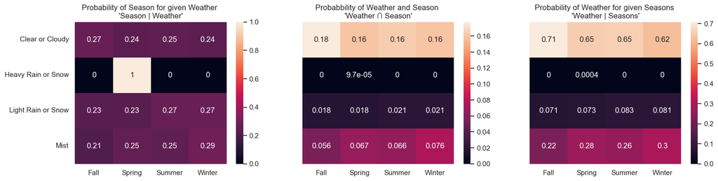

```python
plt.figure(figsize=(18, 4))
# plt.suptitle("Relation of Weather & Season")

plt.subplot(131)
sns.heatmap(pd.crosstab(
    df_yulu['weather'], df_yulu['season'], normalize='index'), annot=True)
plt.title("Probability of Season for given Weather \n'Season | Weather'", fontsize=12)
plt.ylabel("")
plt.xlabel("")

plt.subplot(132)
sns.heatmap(pd.crosstab(
    df_yulu['weather'], df_yulu['season'], normalize='all'), annot=True)
plt.title("Probabbility of Weather and Season \n'Weather ∩ Season'", fontsize=12)
plt.yticks([])
plt.ylabel("")
plt.xlabel("")

plt.subplot(133)
sns.heatmap(pd.crosstab(
    df_yulu['weather'], df_yulu['season'], normalize='columns'), annot=True)
plt.title(
    "Probability of Weather for given Seasons \n'Weather | Seasons'", fontsize=12)
plt.yticks([])
plt.ylabel("")
plt.xlabel("")

plt.show()
```

##### `Descriptive` Plot

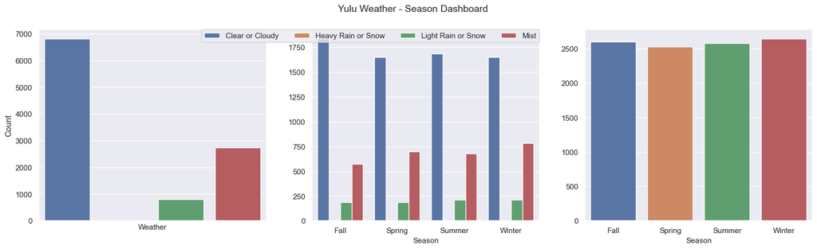

```python
plt.figure(figsize=(20, 5)).suptitle(
    "Yulu Weather - Season Dashboard", fontsize=14)

plt.subplot(1, 3, 1)
sns.countplot(df_yulu, x='weather')
plt.ylabel('Count', fontsize=12)
plt.xlabel('Weather', fontsize=11)
plt.yticks(rotation=0, fontsize=11)
plt.xticks([], fontsize=11)

plt.subplot(1, 3, 2)
sns.countplot(df_yulu, x='season', hue='weather')
plt.ylabel('', fontsize=12)
plt.xlabel('Season', fontsize=11)
plt.yticks(rotation=0, fontsize=11)
plt.xticks(fontsize=11)
plt.legend(borderaxespad=0, ncol=4)

plt.subplot(1, 3, 3)
sns.countplot(df_yulu, x='season')
plt.ylabel('', fontsize=12)
plt.xlabel('Season', fontsize=11)
plt.yticks(rotation=0, fontsize=11)
plt.xticks(fontsize=11)

plt.show()
```

#### **Hypothesis Testing**

Here, we found that Weather is Dependent on Season

```python
Ho = "Weather is Independent of Season"
Ha = "Weather is Dependent on Season"
```

##### Using `ChiSquare` Test

```python
stats, p_value, dof, data = chi2_contingency(
    pd.crosstab(df_yulu['season'], df_yulu['weather']))
round((stats*100), 4), round((p_value*100), 4)
```

```
(5043.71, 0.0)
```

```python
print(Ha if (p_value < significance_level) else Ho)
```

```
Weather is Dependent on Season
```

### #

> Insight

> Weather is dependent on season

```
    Ho -> Weather is Independent of Season
    Ha -> Weather is Dependent on Season

Using Chi-Square Test p_value found that 0.0%.
```

- As 0% < 1% Thus Rejecting Ho & Accept Ha.

As per Chi-Square Test we can Conclude "Weather is Dependent on Season".

## **Feature Engineering**

```python
yulu_feature = pd.read_csv(
    "./bike_sharing.csv", parse_dates=[0], dayfirst=True)
```

```python
yulu_feature = remove_outlier(yulu_feature, 'count')
```

```python
yulu_feature["time_slot"] = yulu_feature['datetime'].dt.hour.apply(
    lambda x:
    (1 if (x <= 4) else
     (2 if (x <= 9) else
      (3 if (x <= 16) else
       (4 if (
           x <= 21) else 5)
       )
      )
     )
)
```

```python
yulu_feature.info()
```

```
<class 'pandas.core.frame.DataFrame'>
Int64Index: 10583 entries, 0 to 10885
Data columns (total 13 columns):
 #   Column      Non-Null Count  Dtype
---  ------      --------------  -----
 0   datetime    10583 non-null  datetime64[ns]
 1   season      10583 non-null  int64
 2   holiday     10583 non-null  int64
 3   workingday  10583 non-null  int64
 4   weather     10583 non-null  int64
 5   temp        10583 non-null  float64
 6   atemp       10583 non-null  float64
 7   humidity    10583 non-null  int64
 8   windspeed   10583 non-null  float64
 9   casual      10583 non-null  int64
 10  registered  10583 non-null  int64
 11  count       10583 non-null  int64
 12  time_slot   10583 non-null  int64
dtypes: datetime64[ns](1), float64(3), int64(9)
memory usage: 1.1 MB
```

```python
yulu_feature['count'].describe()
```

```
count    10583.000000
mean       175.583483
std        156.180672
min          1.000000
25%         40.000000
50%        138.000000
75%        270.000000
max        646.000000
Name: count, dtype: float64
```

### Segmentation Using Inner Quartile Range

```python
# count_Q1 = yulu_feature['count'].quantile(0.25)
# count_median = yulu_feature['count'].median()
# count_mean = yulu_feature['count'].mean()
# count_Q3 = yulu_feature['count'].quantile(0.75)
# count_IQR = count_Q3 - count_Q1
# count_lower = count_Q1 - 1.5*count_IQR
# count_upper = count_Q3 + 1.5*count_IQR
```

```python
# def count_to_feature(x):
#     if (int(x) < count_lower):
#         return "Outliers"
#     elif (int(x) < count_Q1):
#         return 'Bed'
#     elif (int(x) < count_median):
#         return 'Not Good'
#     elif (int(x) < count_mean):
#         return 'Average'
#     elif (int(x) < count_Q3):
#         return 'Good'
#     elif (int(x) < count_upper):
#         return 'Exceptional'
#     else:
#         return "Outliers"


# yulu_feature['performance'] = yulu_feature.apply(
#     lambda row: count_to_feature(row['count']), axis=1)
```

```python
# def target_feature(x):
#     if ((x == 'Outliers') or (x == 'Bed') or (x == 'Not Good')):
#         return 0
#     else:
#         return 1

# yulu_feature['target'] = yulu_feature.apply(
#     lambda row: target_feature(row['performance']), axis=1)
```

### Segmentation Using Z-Score

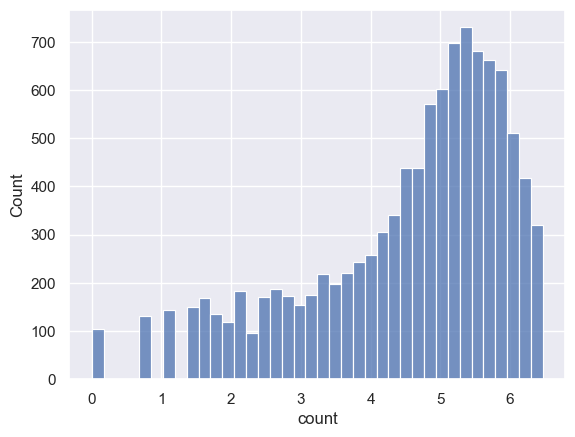

```python
sns.histplot(np.log(yulu_feature['count']))
```

```python
def count_to_feature(x):
    if (x < -1):
        return 'Bed'
    elif (x < -0.5):
        return 'Not Good'
    elif (x < 0.5):
        return 'Average'
    elif (x < 1):
        return 'Good'
    elif (x < 1.5):
        return 'Exceptional'
    else:
        return "Outliers"
    return (x)


yulu_feature['performance'] = zscore(yulu_feature['count']).apply(
    lambda x: count_to_feature(x))
```

```python
yulu_feature['performance'].describe()
```

```
count       10583
unique          6
top       Average
freq         3415
Name: performance, dtype: object
```

```python
yulu_feature['target'] = zscore(yulu_feature['count']).apply(
    lambda x: 1 if -(0.5) < x < (1.5) else 0)
```

### Test The Segmentation

```python
yulu_feature.groupby(['target', 'performance'])['count'].count(
).reset_index().sort_values(['target', 'count'], ascending=False).reset_index(drop=True)
```

|  | target | performance | count |
| --- | --- | --- | --- |
| 0 | 1 | Average | 3415 |
| 1 | 1 | Good | 1088 |
| 2 | 1 | Exceptional | 751 |
| 3 | 0 | Not Good | 2461 |
| 4 | 0 | Bed | 1799 |
| 5 | 0 | Outliers | 1069 |

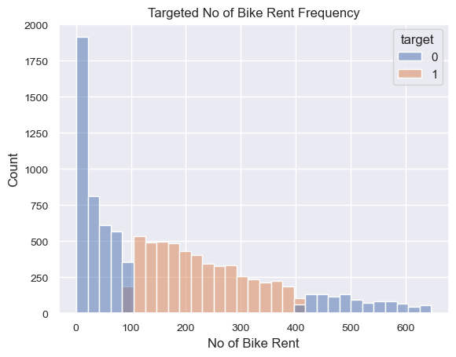

```python
sns.histplot(data=yulu_feature, x='count', hue='target')
plt.title("Targeted No of Bike Rent Frequency")
plt.ylabel('Count', fontsize=12)
plt.xlabel('No of Bike Rent', fontsize=12)
plt.yticks(rotation=0, fontsize=10)
plt.xticks(fontsize=10)
# plt.legend(borderaxespad=0, ncol=4)
plt.show()
```

### Co-Relation of Targeted Variable & Independent Variable

```python
corelation_of_effective_variables = round(yulu_feature[['time_slot', 'workingday', 'season',  'weather',
                                                        'atemp', 'humidity', 'windspeed', 'target'
                                                        ]].corr(), 2)
```

```python
corelation_of_effective_variables
```

|  | time_slot | workingday | season | weather | atemp | humidity | windspeed | target |
| --- | --- | --- | --- | --- | --- | --- | --- | --- |
| time_slot | 1.00 | -0.00 | -0.01 | -0.02 | 0.11 | -0.25 | 0.13 | 0.38 |
| workingday | -0.00 | 1.00 | -0.01 | 0.03 | 0.02 | -0.01 | 0.02 | 0.07 |
| season | -0.01 | -0.01 | 1.00 | 0.01 | 0.27 | 0.19 | -0.15 | 0.12 |
| weather | -0.02 | 0.03 | 0.01 | 1.00 | -0.05 | 0.41 | 0.01 | -0.05 |
| atemp | 0.11 | 0.02 | 0.27 | -0.05 | 1.00 | -0.03 | -0.06 | 0.21 |
| humidity | -0.25 | -0.01 | 0.19 | 0.41 | -0.03 | 1.00 | -0.32 | -0.19 |
| windspeed | 0.13 | 0.02 | -0.15 | 0.01 | -0.06 | -0.32 | 1.00 | 0.08 |
| target | 0.38 | 0.07 | 0.12 | -0.05 | 0.21 | -0.19 | 0.08 | 1.00 |

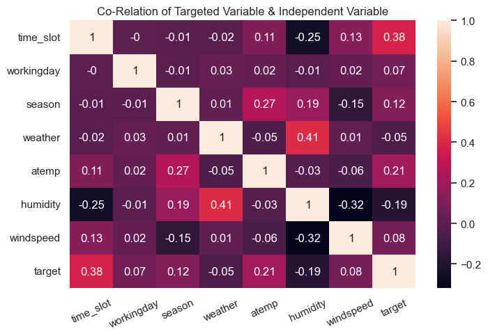

```python
plt.figure(figsize=(8, 5))
plt.title("Co-Relation of Targeted Variable & Independent Variable")
sns.heatmap(corelation_of_effective_variables, annot=True)
plt.xticks(rotation=25)
plt.show()
```